# Topology Qualifying Exam Solutions

# 1 Preface

A great deal of credit for this document goes to Mike Usher, who created an initial PDF of past UGA qual questions organized by topic. Here is a list of problems that Mike recommended reviewing during our problem sessions in Spring 2020:

- Section 1, Point-Set: 8, 10, 11, 14, 16, 19, 22, 23, 27 (Bolzano Weierstrass), 30 (Standard, see counterexamples), 31, 32, 38, 42, 44
- Section 2, Fundamental Group: 1
- Section 3, Covering Spaces: 1b and c, 2, 3, 6, 7, 8, 10 (not really about surfaces per se), 11, 12, 13, 14, 16
- Section 4, Homology/Degree Theory: 2, 4, 5, 8, 13, 19, 21, 22
- Section 5, Cell Complexes/Attaching: 1, 5, 10, 16
- Section 6, Surfaces: 3, 6, 7, 11, 14
- Section 7, Fixed Points: 4, 6, 12, 13, 14
- Section 8, Misc Algebraic Topology: 1, 3, 6, 8

Usually 30% of the problems on any given qual are related to point-set/general Topology. Note that this material is not covered in the course!

# 2 General Topology

## 2.1 Topologies, Subspaces, Closures, and Maps

### 2.1.1 Fall ’11 $\done$

Let $X$ be a topological space, and $B \subset A \subset X$. Equip $A$ with the subspace topology, and write ${ \operatorname{cl}} _X (B)$ or ${ \operatorname{cl}} _A (B)$ for the closure of $B$ as a subset of, respectively, $X$ or $A$.

Determine, with proof, the general relationship between ${ \operatorname{cl}} _X (B) \cap A$ and ${ \operatorname{cl}} _A (B)$

> I.e., are they always equal? Is one always contained in the other but not conversely? Neither?
- Definition of closure: for $A\subseteq X$, ${ \operatorname{cl}} _X(A)$ is the intersection of all $B\supseteq A$ which are closed in $X$.
- Definition of “relative” closure: for $A\subseteq Y \subseteq X$, ${ \operatorname{Cl}} _Y(A)$ is the intersection of all $B$ such that $Y\supseteq B \supseteq A$ which are closed in $Y$.
- Closed sets in a subspace: $B' \subseteq Y\subseteq X$ is closed in $Y$ if $B' = B\cap Y$ for some $B'$ closed in $X$.

What’s the picture? Just need to remember what the closure with respect to a subspace looks like:

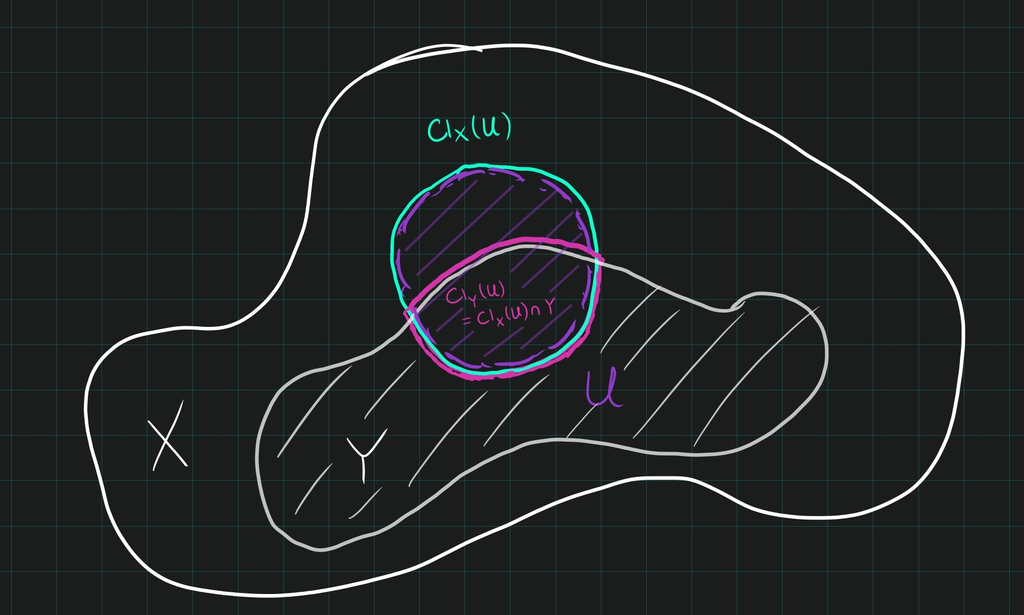

image_2021-05-20-23-58-56

- Claim: ${ \operatorname{Cl}} _X(A) \cap Y = { \operatorname{Cl}} _Y(A)$.
- Write ${ \operatorname{Cl}} _Y(A)$ as the intersection of $B'$ where $Y\supseteq B' \supseteq A$ with $B'$ closed in $Y$.
- Every such $B'$ is of the form $B' = B \cap Y$ for some $B$ closed in $X$.
- Just identify the two sides directly by reindexing the intersection:
  $$\begin{align*}
  { \operatorname{Cl}} _Y(A)
  &\mathrel{\vcenter{:}}=\displaystyle\bigcap_{\substack{ Y\supseteq B' \supseteq A \\ B' \text{ closed in } Y}} B' \\
  &= \displaystyle\bigcap_{\substack{ X \supseteq B \cap Y \supseteq A \\ B \text{ closed in } X}} \qty{ B \cap Y } \\
  &= \qty{ \displaystyle\bigcap_{\substack{ X \supseteq B \cap Y \supseteq A \\ B \text{ closed in } X}} B} \cap Y \\ \\
  &\mathrel{\vcenter{:}}={ \operatorname{Cl}} _X(A) \cap Y
  .\end{align*}$$

### 2.1.2 6 (Fall ’05) $\done$

Prove that the unit interval $I$ is compact. Be sure to explicitly state any properties of ${\mathbb{R}}$ that you use.

- Cantor’s intersection theorem: for a topological space, any nested sequence of compact nonempty sets has nonempty intersection.
- Bases for standard topology on ${\mathbb{R}}$.
- Definition of compactness

What’s the picture? Similar to covering $\left\{{1\over n}\right\}\cup\left\{{0}\right\}$: cover $x=0$ with one set, which nets all but finitely many points.

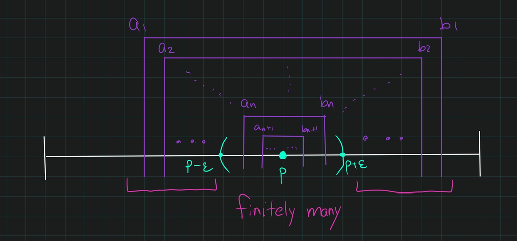

image_2021-05-20-22-46-54

Proceed by contradiction. Binary search down into nested intervals, none of which have finite covers. Get a single point, a single set which eventually contains all small enough nested intervals. Only need finitely many more opens to cover the rest.

- Toward a contradiction, let $\left\{{U_\alpha}\right\} \rightrightarrows[0, 1]$ be an open cover with no finite subcover.
- Then either $[0, {1\over 2}]$ or $[{1\over 2}, 1]$ has no finite subcover; WLOG assume it is $[0, {1\over 2}]$.
- Then either $[0, {1\over 4}]$ or $[{1\over 4}, {1\over 2}]$ has no finite subcover
- Inductively defining $[a_n, b_n]$ this way yields a sequence of compact nested intervals (each with no finite subcover) so Cantor’s Nested Interval theorem applies.
- Since ${\mathbb{R}}$ is a complete metric space and the diameters ${\operatorname{diam}}([a_n, b_n]) \leq {1 \over 2^n} \to 0$, the intersection contains exactly one point.
- Since $p\in [0, 1]$ and the $U_\alpha$ form an open cover, $p\in U_\alpha$ for some $\alpha$.
- Since a basis for $\tau({\mathbb{R}})$ is given by open intervals, we can find an $\varepsilon>0$ such that $(p-\varepsilon, p+\varepsilon) \subseteq U_\alpha$
- Then if ${1\over 2^N} < \varepsilon$, for $n\geq N$ we have
  $$\begin{align*}[a_n, b_n] \subseteq (p-\varepsilon, p+\varepsilon) \subseteq U_\alpha.\end{align*}$$
- But then $U_\alpha \rightrightarrows[a_n, b_n]$, yielding a finite subcover of $[a_n, b_n]$, a contradiction.

### 2.1.3 7 (Fall ’06). $\work$

A topological space is **sequentially compact** if every infinite sequence in $X$ has a convergent subsequence.

Prove that every compact metric space is sequentially compact.

### 2.1.4 8 (Fall ’10). $\done$

Show that for any two topological spaces $X$ and $Y$ , $X \times Y$ is compact if and only if both $X$ and $Y$ are compact.

- Proof of the tube lemma:
- Continuous image of compact is compact.

What’s the picture?

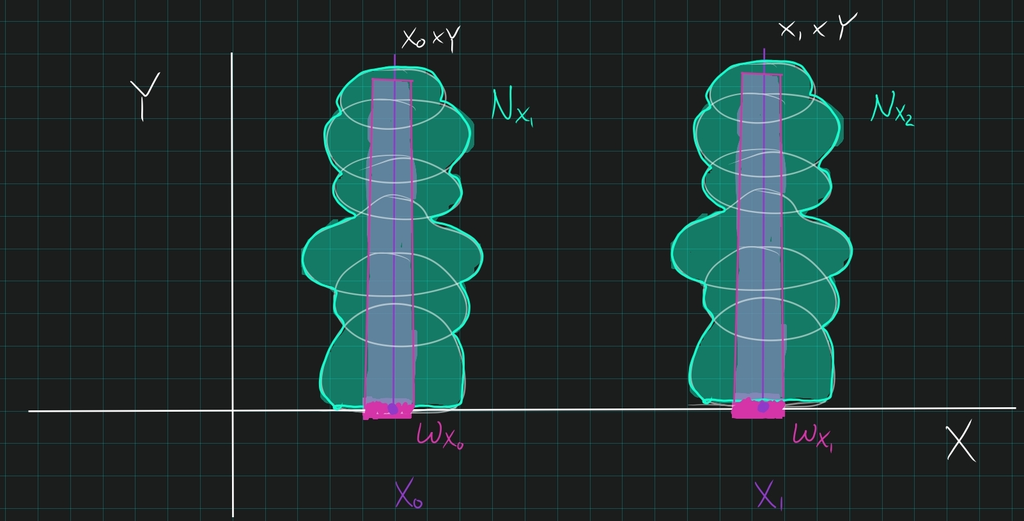

image_2021-05-21-01-16-52

Take an open cover of the product, use that vertical fibers are compact to get a finite cover for each fiber. Use tube lemma to get opens in the base space, run over all $x$ so the tube bases cover $X$. Use that $X$ is compact to get a finite subcover.

$\impliedby$:

- By the universal property, the product $X\times Y$ is equipped with continuous projections $\pi_X: X\times Y\to X$ and $\pi_Y: X\times Y\to X$.
- The continuous image of a compact space is compact, and the images are all of $X$ and $Y$ respectively:
  $$\begin{align*}
  \pi_1(X\times Y) &= X \\
  \pi_2(X\times Y) &= Y
  .\end{align*}$$

$\implies$:

- Let $\left\{{U_j}\right\} \rightrightarrows X\times Y$ be an open cover.
- **Cover a fiber**: fix $x\in X$, the slice $x \times Y$ is homeomorphic to $Y$ and thus compact
- Cover it by finitely many elements $\left\{{U_j}\right\}_{j\leq m} \rightrightarrows{x} \times Y$.

  > Really, cover $Y$, and then cross with $x$ to cover $x \times Y$.
  - Set
    $$\begin{align*}
    N_x \mathrel{\vcenter{:}}=\displaystyle\bigcup_{j\leq m} U_j \supseteq x \times Y
    .\end{align*}$$
  - Apply the tube lemma to $N_x$:
    - Produce a neighborhood $W_x$ of $x$ in $X$ where $W_x \subset N_x$
    - This yields a finite cover:
      $$\begin{align*}
      \left\{{U_j}\right\}_{j\leq m}\rightrightarrows N_x \times Y \supset W_x \times Y \implies \left\{{U_j}\right\}_{j\leq m} \rightrightarrows W_x\times Y
      .\end{align*}$$
- **Cover the base**: let $x\in X$ vary: for each $x\in X$, produce $W_x \times Y$ as above, then $\left\{{W_x}\right\}_{x\in X} \rightrightarrows X$ where each tube $W_x \times Y$ is covered by *finitely* many $U_j$.
- Use that $X$ is compact to produce a finite subcover $\left\{{W_k}\right\}_{k \leq M} \rightrightarrows X$.
- Then $\left\{{W_k\times Y}\right\}_{k\leq M} \rightrightarrows X\times Y$, this is a finite set since each fiber was covered by finitely many opens
  - Finitely many $k$
  - For each $k$, the tube $W_k \times Y$ is covered by finitely by $U_j$
  - And finite $\times$ finite = finite.

### 2.1.5 12 (Spring ’06). $\work$

Write $Y$ for the interval $[0, \infty)$, equipped with the usual topology.

Find, with proof, all subspaces $Z$ of $Y$ which are retracts of $Y$.

- Using the fact that $[0, \infty) \subset {\mathbb{R}}$ is Hausdorff, any retract must be closed, so any closed interval $[\varepsilon, N]$ for $0\leq \varepsilon\leq N \leq \infty$.
  - Note that $\varepsilon= N$ yields all one point sets $\left\{{x_0}\right\}$ for $x_0 \geq 0$.
- No finite discrete sets occur, since the retract of a connected set is connected.

### 2.1.6 13 (Fall ’06). $\work$

1. Prove that if the space $X$ is connected and locally path connected then $X$ is path connected.
2. Is the converse true? Prove or give a counterexample.

### 2.1.7 14 (Fall ’07) $\work$

Let $\left\{{X_\alpha \mathrel{\Big|}\alpha \in A}\right\}$ be a family of connected subspaces of a space $X$ such that there is a point $p \in X$ which is in each of the $X_\alpha$.

Show that the union of the $X_\alpha$ is connected.

- Take two connected sets $X, Y$; then there exists $p\in X\cap Y$.
- Toward a contradiction: write $X\cup Y = A {\textstyle\coprod}B$ with both $A, B \subset A{\textstyle\coprod}B$ open.
- Since $p\in X \cup Y = A{\textstyle\coprod}B$, WLOG $p\in A$. We will show $B$ must be empty.
- Claim: $A\cap X$ is clopen in $X$.
  - $A\cap X$ is open in $X$: ?
  - $A\cap X$ is closed in $X$: ?
- The only clopen sets of a connected set are empty or the entire thing, and since $p\in A$, we must have $A\cap X = X$.
- By the same argument, $A\cap Y = Y$.
- So $A\cap\qty{X\cup Y} = \qty{A\cap X} \cup\qty{A\cap Y} = X\cup Y$
- Since $A\subset X\cup Y$, $A\cap\qty{X\cup Y} = A$
- Thus $A = X\cup Y$, forcing $B = \emptyset$.

Let $X \mathrel{\vcenter{:}}=\cup_\alpha X_\alpha$, and let $p\in \cap X_\alpha$. Suppose toward a contradiction that $X = A {\textstyle\coprod}B$ with $A,B$ nonempty, disjoint, and relatively open as subspaces of $X$. Wlog, suppose $p\in A$, so let $q\in B$ be arbitrary.

Then $q\in X_\alpha$ for some $\alpha$, so $q\in B \cap X_\alpha$. We also have $p\in A \cap X_\alpha$.

But then these two sets disconnect $X_\alpha$, which was assumed to be connected – a contradiction.

### 2.1.8 5 (Fall ’04). $\work$

Let $X$ be a topological space.

1. Prove that $X$ is connected if and only if there is no continuous nonconstant map to the discrete two-point space $\left\{{0, 1}\right\}$.
2. Suppose in addition that $X$ is compact and $Y$ is a connected Hausdorff space. Suppose further that there is a continuous map $f : X \to Y$ such that every preimage $f^{-1}(y)$ for $y \in Y$, is a connected subset of $X$.

Show that $X$ is connected.

3. Give an example showing that the conclusion of (b) may be false if $X$ is not compact.

### 2.1.9 ? (Spring ’10) $\done$

If $X$ is a topological space and $S \subset X$, define in terms of open subsets of $X$ what it means for $S$ **not** to be connected.

Show that if $S$ is not connected there are nonempty subsets $A, B \subset X$ such that
$$\begin{align*}
A \cup B = S {\quad \operatorname{and} \quad} A \cap \mkern 1.5mu\overline{\mkern-1.5muB\mkern-1.5mu}\mkern 1.5mu = \mkern 1.5mu\overline{\mkern-1.5muA\mkern-1.5mu}\mkern 1.5mu \cap B = \emptyset
\end{align*}$$

> Here $\mkern 1.5mu\overline{\mkern-1.5muA\mkern-1.5mu}\mkern 1.5mu$ and $\mkern 1.5mu\overline{\mkern-1.5muB\mkern-1.5mu}\mkern 1.5mu$ denote closure with respect to the topology on the ambient space $X$.
- Topic: closure and connectedness in the subspace topology.
  - See Munkres p.148
- Lemma: $X$ is connected iff the only subsets of $X$ that are closed and open are $\emptyset, X$.
- $S\subset X$ is **not** connected if $S$ with the subspace topology is not connected.
  - I.e. there exist $A, B \subset S$ such that
    - $A, B \neq \emptyset$,
    - $A\cap B = \emptyset$,
    - $A {\textstyle\coprod}B = S$.
- Or equivalently, there exists a nontrivial $A\subset S$ that is clopen in $S$.

Show stronger statement: this is an iff.

$\implies$:

- Suppose $S$ is not connected; we then have sets $A \cup B = S$ from above and it suffices to show ${ \operatorname{cl}} _Y(A) \cap B = A \cap{ \operatorname{cl}} _X(B) = \emptyset$.
- $A$ is open by assumption and $Y\setminus A = B$ is closed in $Y$, so $A$ is clopen.
- Write ${ \operatorname{cl}} _Y(A) \mathrel{\vcenter{:}}={ \operatorname{cl}} _X(A) \cap Y$.
- Since $A$ is closed in $Y$, $A = { \operatorname{cl}} _Y(A)$ by definition, so $A = { \operatorname{cl}} _Y(A) = { \operatorname{cl}} _X(A) \cap Y$.
- Since $A\cap B = \emptyset$, we then have ${ \operatorname{cl}} _Y(A) \cap B = \emptyset$.
- The same argument applies to $B$, so ${ \operatorname{cl}} _Y(B) \cap A = \emptyset$.

$\impliedby$:

- Suppose displayed condition holds; given such $A, B$ we will show they are clopen in $Y$.
- Since ${ \operatorname{cl}} _Y(A) \cap B = \emptyset$, (claim) we have ${ \operatorname{cl}} _Y(A) = A$ and thus $A$ is closed in $Y$.
  - Why?
    $$\begin{align*} { \operatorname{cl}} _Y(A) &\coloneqq{ \operatorname{cl}} _X(A) \cap Y \\ &= { \operatorname{cl}} _X(A) \cap\qty{A{\textstyle\coprod}B} \\ &= \qty{{ \operatorname{cl}} _X(A) \cap A} {\textstyle\coprod}\qty{{ \operatorname{cl}} _X(A) \cap B} \\ &= A {\textstyle\coprod}\qty{{ \operatorname{cl}} _X(A) \cap B} \quad\text{since } A \subset { \operatorname{cl}} _Y(A) \\ &= A {\textstyle\coprod}\qty{{ \operatorname{cl}} _Y(A) \cap B} \quad \text{since } B \subset Y \\ &= A {\textstyle\coprod}\emptyset \quad\text{using the assumption} \\ &= A .\end{align*}$$
- But $A = Y\setminus B$ where $B$ is closed, so $A$ is open and thus a nontrivial clopen subset.

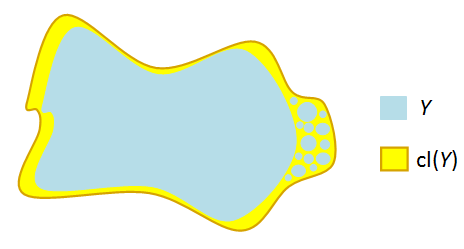

If $S\subset X$ is not connected, then there exists a subset $A\subset S$ that is both open and closed in the subspace topology, where $A\neq \emptyset, S$.

Suppose $S$ is not connected, then choose $A$ as above. Then $B = S\setminus A$ yields a pair $A, B$ that disconnects $S$. Since $A$ is closed in $S$, $\mkern 1.5mu\overline{\mkern-1.5muA\mkern-1.5mu}\mkern 1.5mu = A$ and thus $\mkern 1.5mu\overline{\mkern-1.5muA\mkern-1.5mu}\mkern 1.5mu \cap B = A \cap B = \emptyset$. Similarly, since $A$ is open, $B$ is closed, and $\mkern 1.5mu\overline{\mkern-1.5muB\mkern-1.5mu}\mkern 1.5mu = B \implies \mkern 1.5mu\overline{\mkern-1.5muB\mkern-1.5mu}\mkern 1.5mu \cap A = B \cap A = \emptyset$.

### 2.1.10 ? (Spring ’11) $\work$

A topological space is **totally disconnected** if its only connected subsets are one-point sets.

Is it true that if $X$ has the discrete topology, it is totally disconnected?

Is the converse true? Justify your answers.

### 2.1.11 21 (Fall ’14) $\work$

Let $X$ and $Y$ be topological spaces and let $f : X \to Y$ be a function.

Suppose that $X = A \cup B$ where $A$ and $B$ are closed subsets, and that the restrictions $f \mathrel{\Big|}_A$ and $f \mathrel{\Big|}_B$ are continuous (where $A$ and $B$ have the subspace topology).

Prove that $f$ is continuous.

### 2.1.12 23 (Spring ’15) $\done$

Define a family ${\mathcal{T}}$ of subsets of ${\mathbb{R}}$ by saying that $A \in T$ is $\iff A = \emptyset$ or ${\mathbb{R}}\setminus A$ is a finite set.

Prove that ${\mathcal{T}}$ is a topology on ${\mathbb{R}}$, and that ${\mathbb{R}}$ is compact with respect to this topology.

- This is precisely the cofinite topology.
1. ${\mathbb{R}}\in \tau$ since ${\mathbb{R}}\setminus {\mathbb{R}}= \emptyset$ is trivially a finite set, and $\emptyset \in \tau$ by definition.
2. If $U_i \in \tau$ then $(\cup_i U_i)^c = \cap U_i^c$ is an intersection of finite sets and thus finite, so $\cup_i U_i \in \tau$.
3. If $U_i \in \tau$, then $(\cap_{i=1}^n U_i)^c = \cup_{i=1}^n U_i^c$ is a finite union of finite sets and thus finite, so $\cap U_i \in \tau$.

So $\tau$ forms a topology.

To see that $({\mathbb{R}}, \tau)$ is compact, let $\left\{{U_i}\right\} \rightrightarrows {\mathbb{R}}$ be an open cover by elements in $\tau$.

Fix any $U_\alpha$, then $U_\alpha^c = \left\{{p_1, \cdots, p_n}\right\}$ is finite, say of size $n$. So pick $U_1 \ni p_1, \cdots, U_n \ni p_n$; then ${\mathbb{R}}\subset U_\alpha \cup_{i=1}^n U_i$ is a finite cover.

### 2.1.13 25 (Fall ’16) $\work$

Let ${\mathcal{S}}, {\mathcal{T}}$ be topologies on a set $X$. Show that ${\mathcal{S}}\cap {\mathcal{T}}$ is a topology on $X$.

Give an example to show that ${\mathcal{S}}\cup {\mathcal{T}}$ need not be a topology.

### 2.1.14 42 (Spring ’10) $\done$

Define an equivalence relation $\sim$ on ${\mathbb{R}}$ by $x \sim y$ if and only if $x - y \in {\mathbb{Q}}$. Let $X$ be the set of equivalence classes, endowed with the quotient topology induced by the canonical projection $\pi : {\mathbb{R}}\to X$.

Describe, with proof, all open subsets of $X$ with respect to this topology.

### 2.1.15 43 (Fall ’12) $\work$

Let $A$ denote a subset of points of $S^2$ that looks exactly like the capital letter A. Let $Q$ be the quotient of $S^2$ given by identifying all points of $A$ to a single point.

Show that $Q$ is homeomorphic to a familiar topological space and identify that space.

## 2.2 Compactness and Metric Spaces

### 2.2.1 1 (Spring ’06) $\work$

Suppose $(X, d)$ is a metric space. State criteria for continuity of a function $f : X \to X$ in terms of:

1. open sets;
2. $\varepsilon$’s and $\delta$’s; and
3. convergent sequences.

Then prove that (iii) implies (i).

### 2.2.2 26 (Fall ’17) $\work$

Let $f : X \to Y$ be a continuous function between topological spaces.

Let $A$ be a subset of $X$ and let $f (A)$ be its image in $Y$ .

One of the following statements is true and one is false. Decide which is which, prove the true statement, and provide a counterexample to the false statement:

1. If $A$ is closed then $f (A)$ is closed.
2. If $A$ is compact then $f (A)$ is compact.

### 2.2.3 2 (Spring ’12) $\work$

Let $X$ be a topological space.

1. State what it means for $X$ to be compact.
2. Let $X = \left\{{0}\right\} \cup \left\{{{1\over n} \mathrel{\Big|}n \in {\mathbb{Z}}^+ }\right\}$. Is $X$ compact?
3. Let $X = (0, 1]$. Is $X$ compact?

See Munkres p.164, especially for (ii).

1. See definitions in review doc.
2. Direct proof:
- Let $\left\{{U_i {~\mathrel{\Big|}~}j\in J}\right\}\rightrightarrows X$; then $0\in U_j$ for some $j\in J$.
- In the subspace topology, $U_i$ is given by some $V\in \tau({\mathbb{R}})$ such that $V\cap X = U_i$
  - A basis for the subspace topology on ${\mathbb{R}}$ is open intervals, so write $V$ as a union of open intervals $V = \cup_{k\in K} I_k$.
  - Since $0\in U_j$, $0\in I_k$ for some $k$.
- Since $I_k$ is an interval, it contains infinitely many points of the form $x_n = {1 \over n} \in X$
- Then $I_k \cap X \subset U_j$ contains infinitely many such points.
- So there are only *finitely* many points in $X\setminus U_j$, each of which is in $U_{j(n)}$ for some $j(n) \in J$ depending on $n$.
3. Todo

### 2.2.5 4 (Spring ’05) $\done$

Suppose $(X, d)$ is a compact metric space and $U$ is an open covering of $X$.

Prove that there is a number $\delta > 0$ such that for every $x \in X$, the ball of radius $\delta$ centered at $x$ is contained in some element of $U$.

Statement: show that the *Lebesgue number* is well-defined for compact metric spaces.

> Note: this is a question about the *Lebesgue Number*. See Wikipedia for detailed proof.
- Write $U = \left\{{U_i {~\mathrel{\Big|}~}i\in I}\right\}$, then $X \subseteq \cup_{i\in I} U_i$. Need to construct a $\delta > 0$.
- By compactness of $X$, choose a finite subcover $U_1, \cdots, U_n$.
- Define the distance between a point $x$ and a set $Y\subset X$: $d(x, Y) = \inf_{y\in Y} d(x, y)$.
  - **Claim**: the function $d({-}, Y): X\to {\mathbb{R}}$ is continuous for a fixed set.
  - Proof: Todo, not obvious.

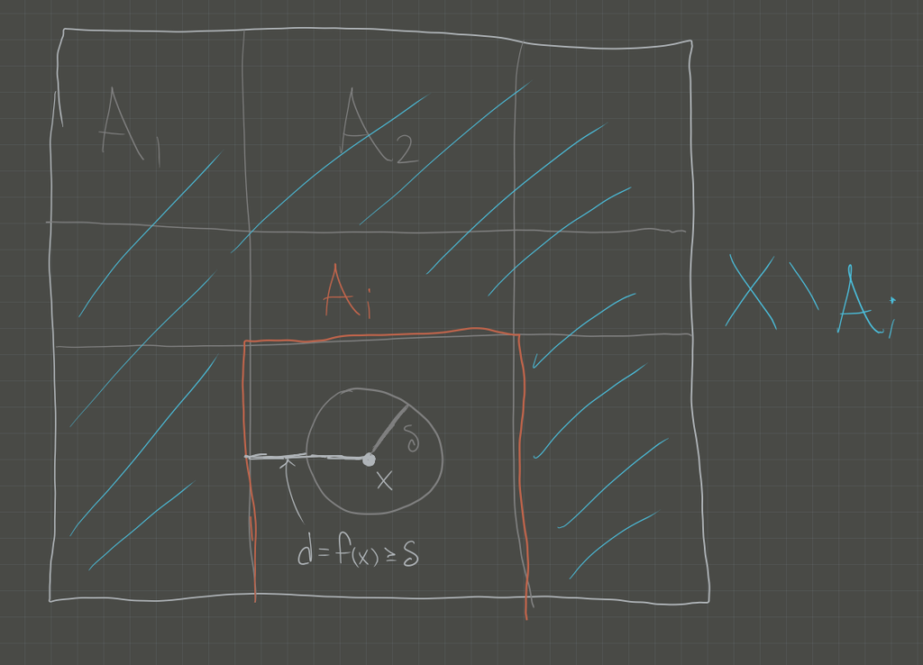

- Define a function
  $$\begin{align*} f: X &\to {\mathbb{R}}\\ x &\mapsto {1\over n} \sum_{i=1}^n d(x, X\setminus U_i) .\end{align*}$$
  - Note this is a sum of continuous functions and thus continuous.
- **Claim**: \begin{align*}\delta \mathrel{\vcenter{:}}=\inf_{x\in X}f(x) = \min_{x\in X}f(x) = f(x_{\text{min}}) > 0\end{align*} suffices.
  - That the infimum is a minimum: $f$ is a continuous function on a compact set, apply the extreme value theorem: it attains its minimum.
  - That $\delta > 0$: otherwise, $\delta = 0 \implies \exists x_0$ such that $d(x_0, X\setminus U_i) = 0$ for all $i$.
    - Forces $x_0 \in X\setminus U_i$ for all $i$, but $X\setminus \cup U_i = \emptyset$ since the $U_i$ cover $X$.
  - That it satisfies the Lebesgue condition: \begin{align*}\forall x\in X, \exists i {\quad \operatorname{such that} \quad} B_\delta(x) \subset U_i\end{align*}
    - Let $B_\delta(x) \ni x$; then by minimality $f(x) \geq \delta$.
    - Thus it can *not* be the case that $d(x, X\setminus U_i) < \delta$ for *every* $i$, otherwise
      $$\begin{align*}f(x) \leq {1\over n}\qty{ \delta + \cdots + \delta} = {n\delta \over n} = \delta\end{align*}$$
    - So there is some particular $i$ such that $d(x, X\setminus U_i) \geq \delta$.
    - But then $B_\delta \subseteq U_i$ as desired.

### 2.2.6 44 (Spring ’15) $\work$

1. Prove that a topological space that has a countable base for its topology also contains a countable dense subset.
2. Prove that the converse to (a) holds if the space is a metric space.

### 2.2.7 18 (Fall ’07) $\done$

- Define a new function
  $$\begin{align*} g: X \to {\mathbb{R}}\\ x &\mapsto d_X(x, f(x)) .\end{align*}$$
- Attempt to minimize. Claim: $g$ is a continuous function.
- Given claim, a continuous function on a compact space attains its infimum, so set
  $$\begin{align*} m \coloneqq\inf_{x\in X} g(x) \end{align*}$$
  and produce $x_0\in X$ such that $g(x) = m$.
- Then
  $$\begin{align*} m> 0 \iff d(x_0, f(x_0)) > 0 \iff x_0 \neq f(x_0) .\end{align*}$$
- Now apply $f$ and use the assumption that $f$ is a contraction to contradict minimality of $m$:
  $$\begin{align*} d(f(f(x_0)), f(x_0)) &\leq C\cdot d(f(x_0), x_0) \\ &< d(f(x_0), x_0) \quad\text{since } C<1\\ &\leq m \end{align*}$$
- Proof that $g$ is continuous: use the definition of $g$, the triangle inequality, and that $f$ is a contraction:
  $$\begin{align*} d(x, f(x)) &\leq d(x, y) + d(y, f(y)) + d(f(x), f(y)) \\ \implies d(x, f(x)) - d(y, f(y)) &\leq d(x, y) + d(f(x), f(y)) \\ \implies g(x) - g(y) &\leq d(x, y) + C\cdot d(x, y) = (C+1) \cdot d(x, y)\\ \end{align*}$$
  - This shows that $g$ is Lipschitz continuous with constant $C+1$ (implies uniformly continuous, but not used).

### 2.2.8 19 (Spring ’15) $\done$

Prove that the product of two connected topological spaces is connected.

- Use the fact that a union of spaces containing a common point is still connected.
- Fix a point $(a, b) \in X \times Y$.
- Since the horizontal slice $X_b\mathrel{\vcenter{:}}= X \times\left\{{b}\right\}$ is homeomorphic to $X$ which is connected, as are all of the vertical slices $Y_x \mathrel{\vcenter{:}}=\left\{{x}\right\} \times Y \cong Y$ (for any $x$), the “T-shaped” space $T_x \mathrel{\vcenter{:}}= X_b \cup Y_x$ is connected for each $x$.
- Note that $(a, b) \in T_x$ for every $x$, so $\cup_{x\in X} T_x = X \times Y$ is connected.

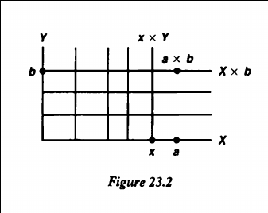

Image

### 2.2.9 20 (Fall ’14) $\done$

Define what it means for a topological space to be:

1. **Connected**
2. **Locally connected**
2. Give, with proof, an example of a space that is connected but not locally connected.
- Consider ${\mathbb{R}}$, unions of intervals, ${\mathbb{Q}}$, and the topologists sine curve.

See definitions in review doc.

$X\mathrel{\vcenter{:}}=$ the Topologist’s sine curve suffices.

- Claim 1: $X$ is connected.
  - Intervals and graphs of cts functions are connected, so the only problem point is $0$.
- Claim 2: $X$ is **not** locally connected.
  - Take any $B_\varepsilon(0) \in {\mathbb{R}}^2$; then projecting onto the subspace $\pi_X(B_\varepsilon(0))$ yields infinitely many arcs, each intersecting the graph at two points on ${{\partial}}B_\varepsilon(0)$.
  - These are homeomorphic to a collection of disjoint embedded open intervals, and any disjoint union of intervals is clearly not connected.

### 2.2.10 22 (Fall ’18) $\work$

Let $X$ be a compact space and let $f : X \times R \to R$ be a continuous function such that $f (x, 0) > 0$ for all $x \in X$.

Prove that there is $\varepsilon> 0$ such that $f (x, t) > 0$ whenever ${\left\lvert {t} \right\rvert} < \varepsilon$.

Moreover give an example showing that this conclusion may not hold if $X$ is not assumed compact.

### 2.2.11 24 (Spring ’16) $\work$

In each part of this problem $X$ is a compact topological space. Give a proof or a counterexample for each statement.

1. If $\left\{{F_n }\right\}_{n=1}^\infty$ is a sequence of nonempty *closed* subsets of $X$ such that $F_{n+1} \subset F_{n}$ for all $n$ then
   $$\begin{align*}\cap^\infty_{n=1} F_n\neq \emptyset.\end{align*}$$
2. If $\left\{{O_n}\right\}_{n=1}^\infty$ is a sequence of nonempty *open* subsets of $X$ such that $O_{n+1} \subset O_n$ for all $n$ then
   $$\begin{align*}\cap_{n=1}^\infty O_{n}\neq \emptyset.\end{align*}$$

### 2.2.12 27 (Fall ’17) $\work$

A metric space is said to be **totally bounded** if for every $\varepsilon> 0$ there exists a finite cover of $X$ by open balls of radius $\varepsilon$.

1. Show: a metric space $X$ is totally bounded iff every sequence in $X$ has a Cauchy subsequence.
2. Exhibit a complete metric space $X$ and a closed subset $A$ of $X$ that is bounded but not totally bounded.

> You are not required to prove that your example has the stated properties.
- Use diagonal trick to construct the Cauchy sequence.

$\implies$:

If $X$ is totally bounded, let $\varepsilon = \frac 1 n$ for each $n$, and let $\left\{{x_i}\right\}$ be an arbitrary sequence. For $n=1$, pick a finite open cover $\left\{{U_i}\right\}_n$ such that ${\operatorname{diam}}{U_i} < \frac 1 n$ for every $i$.

Choose $V_1$ such that there are infinitely many $x_i \in V_1$. (Why?) Note that ${\operatorname{diam}}V_i < 1$. Now choose $x_i \in V_1$ arbitrarily and define it to be $y_1$.

Then since $V_1$ is totally bounded, repeat this process to obtain $V_2 \subseteq V_1$ with ${\operatorname{diam}}(V_2)< \frac 1 2$, and choose $x_i \in V_2$ arbitrarily and define it to be $y_2$.

This yields a nested family of sets $V_1 \supseteq V_2 \supseteq \cdots$ and a sequence $\left\{{y_i}\right\}$ such that $d(y_i, y_j) < \max(\frac 1 i, \frac 1 j) \to 0$, so $\left\{{y_i}\right\}$ is a Cauchy subsequence.

$\impliedby$:

Then fix $\varepsilon > 0$ and pick $x_1$ arbitrarily and define $S_1 = B(\varepsilon, x_1)$. Then pick $x_2 \in S_1^c$ and define $S_2 = S_1 \cup B(\varepsilon, x_2)$, and so on. Continue by picking $x_{n+1} \in S_n^c$ (Since $X$ is not totally bounded, this can always be done) and defining $S_{n+1} = S_n \cup B(\varepsilon, x_{n+1})$.

Then $\left\{{x_n}\right\}$ is not Cauchy, because $d(x_i, x_j) > \varepsilon$ for every $i\neq j$.

Take $X = C^0([0, 1])$ with the sup-norm, then $f_n(x) = x^n$ are all bounded by 1, but ${\left\lVert {f_i - f_j} \right\rVert} = 1$ for every $i, j$, so no subsequence can be Cauchy, so $X$ can not be totally bounded.

Moreover, $\left\{{f_n}\right\}$ is closed. (Why?)

### 2.2.13 Spring ’19 #1 $\done$

Is every complete bounded metric space compact? If so, give a proof; if not, give a counterexample.

- Complete and **totally** bounded $\implies$ compact.
- Definition: A space $X$ is *totally bounded* if for every $\varepsilon >0$, there is a finite cover $X \subseteq \cup_\alpha B_\alpha(\varepsilon)$ such that the radius of each ball is less than $\varepsilon$.
- Definition: A subset of a space $S \subset X$ is *bounded* if there exists a $B(r)$ such that $r<\infty$ and $S \subseteq B(r)$
- Totally bounded $\implies$ bounded
  - Counterexample to converse: ${\mathbb{N}}$ with the discrete metric.
  - Equivalent for Euclidean metric
- Compact $\implies$ totally bounded.
- Counterexample for problem: the unit ball in any Hilbert (or Banach) space of infinite dimension is closed, bounded, and not compact.
- Second counterexample: $({\mathbb{R}}, (x,y) \mapsto \frac{{\left\lvert {x-y} \right\rvert}}{1 + {\left\lvert {x-y} \right\rvert}})$.
- Best counterexample: $X = \left({\mathbb{Z}}, ~\rho ( x , y ) = \left\{ \begin{array} { l l } { 1 } & { \text { if } x \neq y } \\ { 0 } & { \text { if } x = y } \end{array} \right.\right)$. This metric makes $X$ complete for any $X$, then take ${\mathbb{N}}\subset X$. All sets are closed, and bounded, so we have a complete, closed, bounded set that is not compact – take that cover $U_i = B(1, i)$.
- Useful tool: $(X, d) \cong_{\text{Top}} (X, \min{(d(x,y), 1)}$ where the RHS is now a bounded space. This preserves all topological properties (e.g. compactness).

Inductively, let $\mathbf{x}_1 \in B(1, \mathbf{0})$ and $A_1 = {\operatorname{span}}{(\mathbf{x}_1)}$, then choose $s = \mathbf{x} + A_1 \in B(1,0)/A_1$ such that ${\left\lVert {s} \right\rVert} = \frac 1 2$ and then a representative $\mathbf{x}_2$ such that ${\left\lVert {\mathbf{x}_2} \right\rVert} \leq 1$. Then ${\left\lVert {\mathbf{x}_2 - \mathbf{x}_1} \right\rVert} \geq \frac 1 2$

Then, let $A_2 = \mathrm{span}(\mathbf{x}_1, \mathbf{x}_2)$, (which is closed) and repeat this for $s = \mathbf{x} + A_2 \in B(1, \mathbf{0})/ A_2$ to get an $\mathbf{x}_3$ such that ${\left\lVert {\mathbf{x}_3 - \mathbf{x}_{\leq 2}} \right\rVert} \geq \frac 1 2$.

This produces a non-convergent sequence in the closed ball, so it can not be compact.

### 2.2.14 Spring 2019 #2 $\done$

Let $X$ be Hausdorff, and recall that the *one-point compactification* $\tilde X$ is given by the following:

- As a set, $\tilde X \mathrel{\vcenter{:}}= X{\textstyle\coprod}\left\{{\infty}\right\}$.
- A subset $U\subseteq \tilde X$ is open iff either $U$ is open in $X$ or is of the form $U = V{\textstyle\coprod}\left\{{\infty}\right\}$ where $V\subset X$ is arbitrary and $X\setminus V$ is compact.

Prove that this description defines a topology on $\tilde X$ making $\tilde X$ compact.

Definition: $(X, \tau)$ where $\tau \subseteq \mathcal P(X)$ is a *topological space* iff

We can write $\overline{(X, \tau)} = (X {\textstyle\coprod}{\operatorname{pt}}, \tau \cup\tau')$ where $\tau' = \left\{{U{\textstyle\coprod}{\operatorname{pt}}{~\mathrel{\Big|}~}X-U ~\text{is compact}}\right\}$. We need to show that $T \mathrel{\vcenter{:}}=\tau \cup\tau'$ forms a topology.

- We have $\emptyset,X \in \tau \implies \emptyset, X \in \tau \cup\tau'$.
- We just need to check that $\tau'$ is closed under arbitrary unions. Let $\left\{{U_i}\right\} \subset \tau'$, so $X-U_i = K_i$ a compact set for each $i$. Then $\cup_{i} U_i = \cup_i X- (X-U_i)= \cup_i X - K_i = X - \cup_i K_i$

### 2.2.15 Spring 2021 #3 $\work$

For nonempty subsets $A, B$ of a metric space $(X, d)$, define the **setwise distance** as
$$\begin{align*}
d(A, B) \mathrel{\vcenter{:}}=\inf \left\{{ d(a, b) {~\mathrel{\Big|}~}a\in A,\, b\in B }\right\}
.\end{align*}$$

> Hint: take $X = \left\{{ 0 }\right\} \cup(1, 2] \subset {\mathbb{R}}$. Throughout this problem, you may use without proof that the map $d:X\times X\to {\mathbb{R}}$ is continuous.

## 2.3 Connectedness

### 2.3.1 9 (Spring ’13) $\work$

Recall that a topological space is said to be **connected** if there does not exist a pair $U, V$ of disjoint nonempty subsets whose union is $X$.

1. Prove that $X$ is connected if and only if the only subsets of $X$ that are both open and closed are $X$ and the empty set.
2. Suppose that $X$ is connected and let $f : X \to {\mathbb{R}}$ be a continuous map. If $a$ and $b$ are two points of $X$ and $r$ is a point of ${\mathbb{R}}$ lying between $f (a)$ and $f (b)$ show that there exists a point $c$ of $X$ such that $f (c) = r$.

### 2.3.2 10 (Fall ’05) $\done$

Let
$$\begin{align*}
X = \left\{{(0, y) \mathrel{\Big|}- 1 \leq y \leq 1}\right\} \cup \left\{{\qty{x, s = \sin\qty{1 \over x}} \mathrel{\Big|}0 < x \leq 1}\right\}
.\end{align*}$$

Prove that $X$ is connected but not path connected.

$X$ is connected:

To see that $X$ is not path-connected, suppose toward a contradiction that there is a continuous function $f: I \to X \subset {\mathbb{R}}^2$. In particular, $f$ is continuous at $\mathbf{0}$, and so

$$\begin{align*} \forall \varepsilon \quad \exists \delta {~\mathrel{\Big|}~}{\left\lVert {\mathbf{x}} \right\rVert} < \delta \implies {\left\lVert {f(\mathbf{x})} \right\rVert} < \varepsilon .\end{align*}$$

where the norm is the standard Euclidean norm.

However, we can pick $\varepsilon < 1$, say, and consider points of the form $\mathbf{x}_n = (\frac{1}{2n\pi}, 0)$. In particular, we can pick $n$ large enough such that ${\left\lVert {\mathbf{x}_n} \right\rVert}$ is as small as we like, whereas ${\left\lVert {f(\mathbf{x}_n)} \right\rVert} = 1 > \varepsilon$ for all $n$, a contradiction.

### 2.3.3 11 (Fall ’18) $\work$

Let
$$\begin{align*} X=\left\{(x, y) \in \mathbb{R}^{2} | x>0, y \geq 0, \text { and } \frac{y}{x} \text { is rational }\right\} \end{align*}$$
and equip $X$ with the subspace topology induced by the usual topology on ${\mathbb{R}}^2$.

Prove or disprove that $X$ is connected.

- Consider the (continuous) projection $\pi: {\mathbb{R}}^2 \to {\mathbb{RP}}^1$ given by $(x, y) \mapsto [y/x, 1]$ in homogeneous coordinates.
  - I.e. this sends points to lines through the origin with rational slope).
- Note that the image of $\pi$ is ${\mathbb{RP}}^1\setminus\left\{{\infty}\right\}$, which is homeomorphic to ${\mathbb{R}}$.
- If we now define $f = {\left.{{\pi}} \right|_{{X}} }$, we have $f(X) \twoheadrightarrow{\mathbb{Q}}\subset {\mathbb{R}}$.
- If $X$ were connected, then $f(X)$ would also be connected, but ${\mathbb{Q}}\subset {\mathbb{R}}$ is disconnected, a contradiction.

### 2.3.4 Spring 2021 #2

Let $X \mathrel{\vcenter{:}}=\prod_{==1}^{\infty} \left\{{ 0, 1 }\right\}$ endowed with the product topology.

1. Show that for all points $x,y\in X$ with $x\neq y$, there are open subsets $U_x, U_y \subset X$ such that $x\in U_x, y\in U_y$, with $U_x \cup U_y = X$ and $U_x \cap U_y = \emptyset$.
2. Show that $X$ is totally disconnected, i.e. the only nonempty connected subsets of $X$ are singletons.

## 2.4 Hausdorff Spaces and Separation

### 2.4.1 29 (Fall ’14) $\work$

Is every product (finite or infinite) of Hausdorff spaces Hausdorff? If yes, prove it. If no, give a counterexample.

### 2.4.2 30 (Spring ’18) $\done$

Suppose that $X$ is a Hausdorff topological space and that $A \subset X$. Prove that if $A$ is compact in the subspace topology then $A$ is closed as a subset of X.

- Let $A \subset X$ be compact, and pick a fixed $x\in X\setminus A$.
- Since $X$ is Hausdorff, for arbitrary $a\in A$, there exists opens $U_{a} \ni a$ and $U_{x,a}\ni x$ such that $V_{a} \cap U_{x,a} = \emptyset$.
- Then $\left\{{U_{a} {~\mathrel{\Big|}~}a\in A}\right\} \rightrightarrows A$, so by compactness there is a finite subcover $\left\{{U_{a_i}}\right\} \rightrightarrows A$.
- Now take $U = \cup_i U_{a_i}$ and $V_x = \cap_i V_{a_i, x}$, so $U\cap V = \emptyset$.
  - Note that both $U$ and $V_x$ are open.
- But then defining $V \mathrel{\vcenter{:}}=\cup_{x\in X\setminus A} V_x$, we have $X\setminus A \subset V$ and $V\cap A = \emptyset$, so $V = X\setminus A$, which is open and thus $A$ is closed.

### 2.4.3 31 (Spring ’09) $\done$

1. Show that a continuous bijection from a compact space to a Hausdorff space is a homeomorphism.
2. Give an example that shows that the “Hausdorff” hypothesis in part (a) is necessary.
- Continuous bijection + open map (or closed map) $\implies$ homeomorphism.
- **Closed** subsets of compact sets are compact.
- The continuous image of a compact set is compact.
- Compact subsets of Hausdorff spaces are closed.

We’ll show that $f$ is a closed map.

Let $U \in X$ be closed.

- Since $X$ is compact, $U$ is compact
- Since $f$ is continuous, $f(U)$ is compact
- Since $Y$ is Hausdorff, $f(U)$ is closed.

Note that any finite space is clearly compact.

Take $f: ([2], \tau_1) \to ([2], \tau_2)$ to be the identity map, where $\tau_1$ is the discrete topology and $\tau_2$ is the indiscrete topology. Any map into an indiscrete topology is continuous, and $f$ is clearly a bijection.

Let $g$ be the inverse map; then note that $1 \in \tau_1$ but $g^{-1}(1) = 1$ is not in $\tau_2$, so $g$ is not continuous.

### 2.4.4 32 (Fall ’14) $\done$

Let $X$ be a topological space and let
$$\begin{align*}
\Delta = \left\{{(x, y) \in X \times X \mathrel{\Big|}x = y}\right\}
.\end{align*}$$

Show that $X$ is a Hausdorff space if and only if $\Delta$ is closed in $X \times X$.

$\implies$:

- Let $p\in X^2\setminus \Delta$.
- Then $p$ is of the form $(x, y)$ where $x\neq y$ and $x,y\in X$.
- Since $X$ is Hausdorff, pick $N_x, N_y$ in $X$ such that $N_x \cap N_y = \emptyset$.
- Then $N_p\mathrel{\vcenter{:}}= N_x \times N_y$ is an open set in $X^2$ containing $p$.
- Claim: $N_p \cap\Delta = \emptyset$.
  - If $q \in N_p \cap\Delta$, then $q = (z, z)$ where $z\in X$, and $q\in N_p \implies q\in N_x \cap N_y = \emptyset$.
- Then $X^2\setminus \Delta = \cup_p N_p$ is open.

$\impliedby$:

- Let $x\neq y\in X$.
- Consider $(x, y) \in \Delta^c \subset X^2$, which is open.
- Thus $(x, y) \in B$ for some box in the product topology.
- $B = U \times V$ where $U\ni x, V\ni y$ are open in $X$, and $B \subset X^2\setminus \Delta$.
- Claim: $U\cap V = \emptyset$.
  - Otherwise, $z\in U\cap V \implies (z, z) \in B\cap\Delta$, but $B \subset X^2\setminus \Delta \implies B \cap\Delta = \emptyset$.

### 2.4.5 33 (Fall ’06) $\work$

If $f$ is a function from $X$ to $Y$ , consider the graph
$$\begin{align*}
G = \left\{{(x, y) \in X \times Y \mathrel{\Big|}f (x) = y}\right\}
.\end{align*}$$

1. Prove that if $f$ is continuous and $Y$ is Hausdorff, then $G$ is a closed subset of $X \times Y$.
2. Prove that if $G$ is closed and $Y$ is compact, then $f$ is continuous.

### 2.4.6 34 (Fall ’04) $\work$

Let X be a noncompact locally compact Hausdorff space, with topology ${\mathcal{T}}$. Let $\tilde X = X \cup \left\{{\infty}\right\}$ ($X$ with one point adjoined), and consider the family ${\mathcal{B}}$ of subsets of $\tilde X$ defined by
$$\begin{align*}
{\mathcal{B}}= T \cup \left\{{S \cup \left\{{\infty}\right\}\mathrel{\Big|}S \subset X,~~ X \backslash S \text{ is compact}}\right\}
.\end{align*}$$

1. Prove that ${\mathcal{B}}$ is a topology on $\tilde X$, that the resulting space is compact, and that $X$ is dense in $\tilde X$.
2. Prove that if $Y \supset X$ is a compact space such that $X$ is dense in $Y$ and $Y \backslash X$ is a singleton, then Y is homeomorphic to $\tilde X$.

> The space $\tilde X$ is called the **one-point compactification** of $X$.
3. Find familiar spaces that are homeomorphic to the one point compactifications of
4. $X = (0, 1)$ and
2. $X = {\mathbb{R}}^2$.

### 2.4.7 35 (Fall ’16) $\work$

Prove that a metric space $X$ is **normal**, i.e. if $A, B \subset X$ are closed and disjoint then there exist open sets $A \subset U \subset X, ~B \subset V \subset X$ such that $U \cap V = \emptyset$.

### 2.4.8 36 (Spring ’06) $\work$

Prove that every compact, Hausdorff topological space is normal.

### 2.4.9 37 (Spring ’09) $\work$

Show that a connected, normal topological space with more than a single point is uncountable.

### 2.4.10 38 (Spring ’08) $\done$

Give an example of a quotient map in which the domain is Hausdorff, but the quotient is not.

- ${\mathbb{R}}$ is clearly Hausdorff, and ${\mathbb{R}}/{\mathbb{Q}}$ has the indiscrete topology, and is thus non-Hausdorff.
- So take the quotient map $\pi:{\mathbb{R}}\to {\mathbb{R}}/{\mathbb{Q}}$.

Direct proof that ${\mathbb{R}}/{\mathbb{Q}}$ isn’t Hausdorff:

- Pick $[x] \subset U \neq [y] \subset V \in {\mathbb{R}}/{\mathbb{Q}}$ and suppose $U\cap V = \emptyset$.
- Pull back $U\to A, V\to B$ open disjoint sets in ${\mathbb{R}}$
- Both $A, B$ contain intervals, so they contain rationals $p\in A, q\in B$
- Then $[p] = [q] \in U\cap V$.

### 2.4.11 39 (Fall ’04) $\work$

Let $X$ be a compact Hausdorff space and suppose $R \subset X \times X$ is a closed equivalence relation. Show that the quotient space $X/R$ is Hausdorff.

### 2.4.12 40 (Spring ’18) $\work$

Let $U \subset {\mathbb{R}}^n$ be an open set which is bounded in the standard Euclidean metric. Prove that the quotient space ${\mathbb{R}}^n / U$ is not Hausdorff.

### 2.4.13 41 (Fall ’09) $\work$

Let $A$ be a closed subset of a normal topological space $X$. Show that both $A$ and the quotient $X/A$ are normal.

### 2.4.14 45 (Spring ’11) $\work$

Recall that a topological space is **regular** if for every point $p \in X$ and for every closed subset $F \subset X$ not containing $p$, there exist disjoint open sets $U, V \subset X$ with $p \in U$ and $F \subset V$.

Let $X$ be a regular space that has a countable basis for its topology, and let $U$ be an open subset of $X$.

1. Show that $U$ is a countable union of closed subsets of $X$.
2. Show that there is a continuous function $f : X \to [0,1]$ such that $f (x) > 0$ for $x \in U$ and $f (x) = 0$ for $x \in U$.

## 2.5 Exercises

### 2.5.1 Basics

#### 2.5.1.1 Exercise $\work$

Show that for $A\subseteq X$, ${ \operatorname{cl}} _X(A)$ is the smallest closed subset containing $A$.

#### 2.5.1.2 Exercise $\done$

Give an example of spaces $A\subseteq B \subseteq X$ such that $A$ is open in $B$ but $A$ is *not* open in $X$.

No: Take $[0, 1] \subset [0, 1] \subset {\mathbb{R}}$. Then $[0, 1]$ is tautologically open in $[0, 1]$ as it is the entire space, But $[0, 1]$ is not open in ${\mathbb{R}}$: - E.g. $\left\{{1}\right\}$ is not an interior point (every neighborhood intersects the complement ${\mathbb{R}}\setminus[0, 1]$).

#### 2.5.1.3 Exercise $\work$

Show that the diagonal map $\Delta(x) = (x, x)$ is continuous.

#### 2.5.1.4 Exercise $\work$

Show that if $A_i \subseteq X$, then ${ \operatorname{cl}} _X(\cup_i A_i) = \cup_i { \operatorname{cl}} _X(A_i)$.

#### 2.5.1.5 Exercise $\work$

Show that ${\mathbb{R}}$ is not homeomorphic to $[0, \infty)$.

#### 2.5.1.6 Exercise $\work$

Show that the set $(x, y) \in {\mathbb{R}}^2$ such that at least one of $x, y$ is rational with the subspace topology is a connected space.

#### 2.5.1.7 Exercise: ${\mathbb{R}}/{\mathbb{Q}}$ is indiscrete

Show that ${\mathbb{R}}/{\mathbb{Q}}$ has the indiscrete topology.

- Let $U \subset {\mathbb{R}}/{\mathbb{Q}}$ be open and nonempty, show $U = {\mathbb{R}}/{\mathbb{Q}}$.
- Let $[x] \in U$, then $x \in \pi^{-1}(U) \mathrel{\vcenter{:}}= V \subset{\mathbb{R}}$ is open.
- Then $V$ contains an interval $(a, b)$
- Every $y\in V$ satisfies $y+q \in V$ for all $q\in {\mathbb{Q}}$, since $y+q-y \in {\mathbb{Q}}\implies [y+q] = [y]$.
- So $(a-q, b+q) \in V$ for all $q\in {\mathbb{Q}}$.
- So $\cup_{q\in {\mathbb{Q}}}(a-q, b+q) \in V \implies {\mathbb{R}}\subset V$.
- So $\pi(V) = {\mathbb{R}}/{\mathbb{Q}}= U$, and thus the only open sets are the entire space and the empty set.

### 2.5.2 Connectedness

#### 2.5.2.1 Exercise $\work$

Prove that $X$ is connected iff the only clopen subsets are $\emptyset, X$.

#### 2.5.2.2 Exercise $\work$

Let $A \subset X$ be a connected subspace.

Show that if $B\subset X$ satisfies $A\subseteq B \subseteq \mkern 1.5mu\overline{\mkern-1.5muA\mkern-1.5mu}\mkern 1.5mu$, then $B$ is connected.

#### 2.5.2.3 Exercise $\work$

Show that: - Connected does not imply path connected - Connected and locally path connected *does* imply path connected - Path connected implies connected

#### 2.5.2.4 Exercise $\work$

Use the fact that intervals are connected to prove the intermediate value theorem.

#### 2.5.2.5 Exercise $\work$

Prove that the continuous image of a connected set is connected.

#### 2.5.2.6 Exercise $\work$

Show that if $X$ is locally path connected, then

- Every open subset of $X$ is again locally path-connected.
- $X$ is connected $\iff X$ is path-connected.
- Every path component of $X$ is a connected component of $X$.
- Every connected component of $X$ is open in $X$.

#### 2.5.2.7 Exercise $\done$

Show that $[0, 1]$ is connected.

(https://sites.math.washington.edu/~morrow/334_16/connected.pdf) [A potentially shorter proof](https://math.stackexchange.com/questions/934421/proof-of-that-every-interval-is-connected)

Let $I = [0, 1] = A\cup B$ be a disconnection, so - $A, B \neq \emptyset$ - $A {\textstyle\coprod}B = I$ - ${ \operatorname{cl}} _I(A) \cap B = A \cap{ \operatorname{cl}} _I(B) = \emptyset$. Let $a\in A$ and $b\in B$ where WLOG $a<b$ - (since either $a<b$ or $b<a$, and $a\neq b$ since $A, B$ are disjoint) Let $K = [a, b]$ and define $A_K \mathrel{\vcenter{:}}= A\cap K$ and $B_K \mathrel{\vcenter{:}}= B\cap K$. Now $A_K, B_K$ is a disconnection of $K$. Let $s = \sup(A_K)$, which exists since ${\mathbb{R}}$ is complete and has the LUB property Claim: $s \in { \operatorname{cl}} _I(A_K)$. Proof: - If $s\in A_K$ there’s nothing to show since $A_K \subset { \operatorname{cl}} _I(A_K)$, so assume $s\in I\setminus A_K$. - Now let $N_s$ be an arbitrary neighborhood of $s$, then using ??? we can find an $\varepsilon>0$ such that $B_\varepsilon(s) \subset N_s$ - Since $s$ is a supremum, there exists an $a\in A_K$ such that $s-\varepsilon< a$. - But then $a \in B_\varepsilon(s)$ and $a\in N_s$ with $a\neq s$. - Since $N_s$ was arbitrary, every $N_s$ contains a point of $A_K$ not equal to $s$, so $s$ is a limit point by definition. Since $s\in { \operatorname{cl}} _I(A_K)$ and ${ \operatorname{cl}} _I(A_K)\cap B_K = \emptyset$, we have $s\not \in B_K$. Then the subinterval $(x, b] \cap A_K = \emptyset$ for every $x>c$ since $c \mathrel{\vcenter{:}}=\sup A_K$. But since $A_K {\textstyle\coprod}B_K = K$, we must have $(x, b] \subset B_K$, and thus $s\in { \operatorname{cl}} _I(B_K)$. Since $A_K, B_K$ were assumed disconnecting, $s\not \in A_K$ But then $s\in K$ but $s\not\in A_K {\textstyle\coprod}B_K = K$, a contradiction.

### 2.5.3 Compactness

#### 2.5.3.1 $\star$ Exercise $\done$

Let $X$ be a compact space and let $A$ be a closed subspace. Show that $A$ is compact.

Let $X$ be compact, $A\subset X$ closed, and $\left\{{U_\alpha}\right\} \rightrightarrows A$ be an open cover. By definition of the subspace topology, each $U_\alpha = V_\alpha \cap A$ for some open $V_\alpha \subset X$, and $A\subset \cup_\alpha V_\alpha$. Since $A$ is closed in $X$, $X\setminus A$ is open. Then $\left\{{V_\alpha}\right\}\cup\left\{{X\setminus A}\right\}\rightrightarrows X$ is an open cover, since every point is either in $A$ or $X\setminus A$. By compactness of $X$, there is a finite subcover $\left\{{U_j {~\mathrel{\Big|}~}j\leq N}\right\}\cup\left\{{X\setminus A}\right\}$ Then $\qty{\left\{{U_j}\right\} \cup\left\{{X\setminus A}\right\}} \cap A \mathrel{\vcenter{:}}=\left\{{V_j}\right\}$ is a finite cover of $A$.

#### 2.5.3.2 $\star$ Exercise $\done$

Let $f : X \to Y$ be a continuous function, with $X$ compact. Show that $f(X)$ is compact.

Let $f:X\to Y$ be continuous with $X$ compact, and $\left\{{U_\alpha}\right\} \rightrightarrows f(X)$ be an open cover. Then $\left\{{f^{-1}(U_\alpha)}\right\} \rightrightarrows X$ is an open cover of $X$, since $x\in X \implies f(x) \in f(X) \implies f(x) \in U_\alpha$ for some $\alpha$, so $x\in f^{-1}(U_\alpha)$ by definition. By compactness of $X$ there is a finite subcover $\left\{{f^{-1}(U_j) {~\mathrel{\Big|}~}j\leq N}\right\} \rightrightarrows X$. Then the finite subcover $\left\{{U_j{~\mathrel{\Big|}~}j\leq N}\right\} \rightrightarrows f(X)$, since if $y\in f(X)$, $y\in U_\alpha$ for some $\alpha$ and thus $f^{-1}(y) \in f^{-1}(U_j)$ for some $j$ since $\left\{{U_j}\right\}$ is a cover of $X$.

Let $A$ be a compact subspace of a Hausdorff space $X$. Show that $A$ is closed.

#### 2.5.3.3 Exercise $\work$

Show that any infinite set with the cofinite topology is compact.

#### 2.5.3.4 Exercise $\work$

Show that every compact metric space is complete.

#### 2.5.3.5 Exercise $\work$

Show that if $X$ is second countable and Hausdorff, or a metric space, then TFAE:

- $X$ is compact
- Every infinite subset $A\subseteq X$ has a limit point in $X$.
- Every sequence in $X$ has a convergent subsequence in $X$.

#### 2.5.3.6 Exercise $\work$

Show that if $f: A\to B$ is a continuous map between metric spaces and $K\subset A$ is compact, then ${\left.{{f}} \right|_{{K}} }$ is uniformly continuous.

#### 2.5.3.7 Exercise $\work$

Show that if $f:X\to Y$ is continuous and $X$ is compact then $f(X)$ is compact.

#### 2.5.3.8 Exercise $\work$

Show that if $f:X\to {\mathbb{R}}$ and $X$ is compact then $f$ is bounded and attains its min/max.

#### 2.5.3.9 Exercise $\work$

Show that a finite product or union compact spaces is again compact.

#### 2.5.3.10 Exercise $\work$

Show that a quotient of a compact space is again compact.

#### 2.5.3.11 Exercise $\work$

Show that if $X$ is compact and $A\subseteq X$ is closed then $A$ is compact.

#### 2.5.3.12 Exercise $\work$

Show that if $X$ is Hausdorff and $A\subseteq X$ is compact then $A$ is closed.

#### 2.5.3.13 Exercise $\work$

Show that if $X$ is a metric space and $A\subseteq X$ is compact then $A$ is bounded.

#### 2.5.3.14 Exercise $\work$

Show that a continuous map from a compact space to a Hausdorff space is closed.

#### 2.5.3.15 Exercise $\work$

Show that an injective continuous map from a compact space to a Hausdorff space is an embedding (a homeomorphism onto its image).

#### 2.5.3.16 Exercise $\work$

Show that $[0, 1]$ is compact.

#### 2.5.3.17 Exercise $\work$

Show that a compact Hausdorff space is is metrizable iff it is second-countable.

#### 2.5.3.18 Exercise $\work$

Show that if $X$ is metrizable, then $X$ is compact

#### 2.5.3.19 Exercise $\work$

Give an example of a space that is compact but not sequentially compact, and vice versa.

#### 2.5.3.20 Exercise $\work$

Show that a sequentially compact space is totally bounded.

#### 2.5.3.21 Exercise $\work$

Show that ${\mathbb{R}}$ with the cofinite topology is compact.

#### 2.5.3.22 Exercise $\work$

Show that $[0, 1]$ is compact without using the Heine-Borel theorem.

### 2.5.4 Separation

#### 2.5.4.1 Exercise $\work$

Show that $X$ is Hausdorff iff $\Delta(X)$ is closed in $X\times X$.

#### 2.5.4.2 Exercise $\work$

Prove that $X, Y$ are Hausdorff iff $X\times Y$ is Hausdorff.

#### 2.5.4.3 Exercise $\work$

Show that ${\mathbb{R}}$ is separable.

#### 2.5.4.4 Exercise $\work$

Show that any space with the indiscrete topology is separable.

#### 2.5.4.5 Exercise $\work$

Show that any countable space with the discrete topology is separable.

#### 2.5.4.6 Exercise $\work$

Show that the minimal uncountable order with the order topology is not separable.

#### 2.5.4.8 Exercise $\work$

Show that every metric space is Hausdorff in its metric topology.

### 2.5.5 Hausdorff Spaces

#### 2.5.5.1 Exercise

Show that a compact set in a Hausdorff space is closed.

#### 2.5.5.2 Exercise $\done$

Let $A\subset X$ with $A$ closed and $X$ compact, and show that $A$ is compact.

Alternative definition of “open”: todo.

- Let $A$ be a compact subset of $X$ a Hausdorff space, we will show $X\setminus A$ is open
- Fix $x\in X\setminus A$.
- Since $X$ is Hausdorff, for every $y\in A$ we can find $U_y \ni y$ and $V_x(y) \ni x$ depending on $y$ such that $U_x(y) \cap U_y = \emptyset$.
- Then $\left\{{U_y {~\mathrel{\Big|}~}y\in A}\right\} \rightrightarrows A$, and by compactness of $A$ there is a finite subcover corresponding to a finite collection $\left\{{y_1, \cdots, y_n}\right\}$.
- **Magic Step**: set $U = \cup U_{y_i}$ and $V = \cap V_x(y_i)$;
  - Note $A\subset U$ and $x\in V$
  - Note $U\cap V = \emptyset$.
- Done: for every $x\in X\setminus A$, we have found an open set $V\ni x$ such that $V\cap A = \emptyset$, so $x$ is an interior point and a set is open iff every point is an interior point.

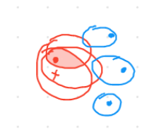

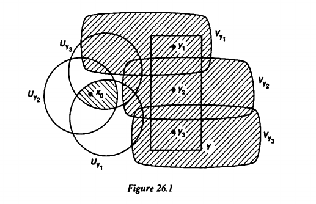

#### 2.5.5.3 Exercise $\done$

Show that a continuous bijection from a compact space to a Hausdorff space is a homeomorphism.

- It suffices to show that $f$ is a closed map, i.e. if $U\subseteq X$ is closed then $f(U)\subseteq Y$ is again closed.
- Let $U\in X$ be closed; since $X$ is closed, $U$ is compact
  - Since closed subsets of compact spaces are compact.
- Since $f$ is continuous, $f(U)$ is compact
  - Since the continuous image of a compact set is compact.
- Since $Y$ is Hausdorff and $f(U)$ is compact, $f(U)$ is closed
  - Since compact subsets of Hausdorff spaces are closed.

#### 2.5.5.4 Exercise $\work$

Show that a closed subset of a Hausdorff space need not be compact.

#### 2.5.5.5 Exercise $\work$

Show that in a *compact* Hausdorff space, $A$ is closed iff $A$ is compact.

#### 2.5.5.6 Exercise $\work$

Show that a local homeomorphism between compact Hausdorff spaces is a covering space.

# 3 The Fundamental Group

## 3.1 1 (Spring ’15) $\done$

Let $S^1$ denote the unit circle in $C$, $X$ be any topological space, $x_0 \in X$, and
$$\begin{align*}\gamma_0, \gamma_1 : S^1 \to X\end{align*}
be two continuous maps such that \(\gamma_0 (1) = \gamma_1 (1) = x_0\).$$

Prove that $\gamma_0$ is homotopic to $\gamma_1$ if and only if the elements represented by $\gamma_0$ and $\gamma_1$ in $\pi_1 (X, x_0 )$ are conjugate.

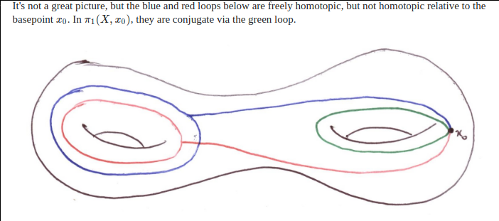

$\implies$:

- Suppose $\gamma_1 \simeq\gamma_2$, then there exists a free homotopy $H: I\times S^1 \to X$ with $H_0 = \gamma_0, H_1 = \gamma_1$.
- Since $H(0, 1) \gamma_0(1) = x_0$ and $H(1, 1) = \gamma_1(1) = x_0$, the map
  $$\begin{align*}
  T: [0, 1] &\to X \\
  t &\mapsto H(t, 1)
  \end{align*}
  descends to a loop \(T:S^1\to X\).$$
- Claim: $\gamma_1$ and $T\ast \gamma_2 \ast T^{-1}$ are homotopic rel $x_0$, making $\gamma_1, \gamma_2$ conjugate in $\pi_1$.
  - Idea: for each fixed $s$, follow $T$ for the first third, $\gamma_2$ for the middle third, $T^{-1}$ for the last third.

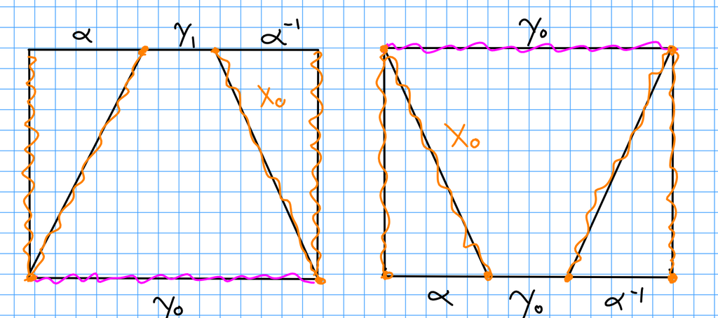

$\impliedby$:

- Suppose $[\gamma_1] = [h] [\gamma_2] [h]^{-1}$ in $\pi_1(X; x_0)$. The claim is that $\gamma_1 \simeq h\gamma_2 h^{-1}$ are freely homotopic.
- Since these are equal in $\pi_1$, we get a square interpolating $\gamma_1$ and $h\gamma_2 h^{-1}$ with constant sides $\operatorname{id}_{x_0}$.
- For free homotopies, the sides don’t have to be constant, to merge $h$ and $h^{-1}$ into the sides to get a free homotopy from $f$ to $g$:

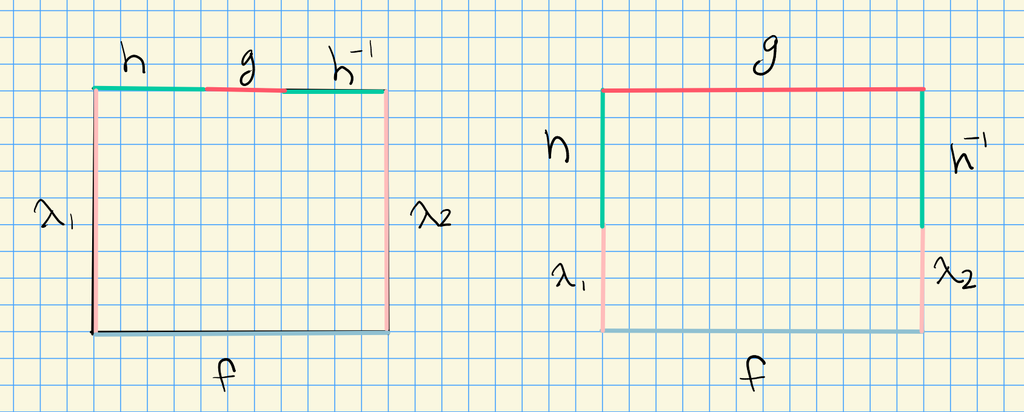

## 3.2 2 (Spring ’09/Spring ’07/Fall ’07/Fall ’06) $\work$

1. State van Kampen’s theorem.
2. Calculate the fundamental group of the space obtained by taking two copies of the torus $T = S^1 \times S^1$ and gluing them along a circle $S^1 \times {p}$ where $p$ is a point in $S^1$.
3. Calculate the fundamental group of the Klein bottle.
4. Calculate the fundamental group of the one-point union of $S^1 \times S^1$ and $S^1$.
5. Calculate the fundamental group of the one-point union of $S^1 \times S^1$ and ${\mathbb{RP}}^2$.

> **Note: multiple appearances!!**

## 3.3 3 (Fall ’18) $\work$

Prove the following portion of van Kampen’s theorem. If $X = A\cup B$ and $A$, $B$, and $A \cap B$ are nonempty and path connected with ${\operatorname{pt}}\in A \cap B$, then there is a surjection
$$\begin{align*}
\pi_1 (A, {\operatorname{pt}}) \ast \pi_1 (B, {\operatorname{pt}}) \to \pi_1 (X, {\operatorname{pt}})
.\end{align*}$$

## 3.4 4 (Spring ’15) $\work$

Let $X$ denote the quotient space formed from the sphere $S^2$ by identifying two distinct points.

Compute the fundamental group and the homology groups of $X$.

## 3.5 5 (Spring ’06) $\work$

Start with the unit disk ${\mathbb{D}}^2$ and identify points on the boundary if their angles, thought of in polar coordinates, differ a multiple of $\pi/2$.

Let $X$ be the resulting space. Use van Kampen’s theorem to compute $\pi_1 (X, \ast)$.

## 3.6 6 (Spring ’08) $\work$

Let $L$ be the union of the $z$-axis and the unit circle in the $xy{\hbox{-}}$plane. Compute $\pi_1 ({\mathbb{R}}^3 \backslash L, \ast)$.

## 3.7 7 (Fall ’16) $\work$

Let $A$ be the union of the unit sphere in ${\mathbb{R}}^3$ and the interval $\left\{{(t, 0, 0) : -1 \leq t \leq 1}\right\} \subset {\mathbb{R}}^3$.

Compute $\pi_1 (A)$ and give an explicit description of the universal cover of $X$.

## 3.8 8 (Spring ’13) $\work$

1. Let $S_1$ and $S_2$ be disjoint surfaces. Give the definition of their connected sum $S^1 \#S^2$.
2. Compute the fundamental group of the connected sum of the projective plane and the two-torus.

## 3.9 9 (Fall ’15) $\work$

Compute the fundamental group, using any technique you like, of ${\mathbb{RP}}^2 \#{\mathbb{RP}}^2 \#{\mathbb{RP}}^2$.

## 3.10 10 (Fall ’11) $\work$

Let
$$\begin{align*}
V = {\mathbb{D}}^2 \times S^1 = \left\{{ (z, e^{it}) {~\mathrel{\Big|}~}{\left\lVert {z} \right\rVert} \leq 1,~~ 0 \leq t < 2\pi}\right\}
\end{align*}
be the “solid torus” with boundary given by the torus \(T = S^1 \times S^1\) .$$

For $n \in {\mathbb{Z}}$ define
$$\begin{align*} \phi_n : T &\to T \\ (e^{is} , e^{it} ) &\mapsto (e^{is} , e^{i(ns+t)}) .\end{align*}$$

Find the fundamental group of the identification space
$$\begin{align*}
V_n = {V{\textstyle\coprod}V \over \sim n}
\end{align*}
where the equivalence relation \(\sim_n\) identifies a point \(x\) on the boundary \(T\) of the first copy of \(V\) with the point \(\phi_n (x)\) on the boundary of the second copy of \(V\).$$

## 3.11 11 (Fall ’16) $\work$

Let $S_k$ be the space obtained by removing $k$ disjoint open disks from the sphere $S^2$. Form $X_k$ by gluing $k$ Möbius bands onto $S_k$ , one for each circle boundary component of $S_k$ (by identifying the boundary circle of a Möbius band homeomorphically with a given boundary component circle).

Use van Kampen’s theorem to calculate $\pi_1 (X_k)$ for each $k > 0$ and identify $X_k$ in terms of the classification of surfaces.

## 3.12 12 (Spring ’13) $\work$

1. Let $A$ be a subspace of a topological space $X$. Define what it means for $A$ to be a **deformation retract** of $X$.
2. Consider $X_1$ the “planar figure eight” and
   $$\begin{align*}X_2 = S^1 \cup ({0} \times [-1, 1])\end{align*}
   (the “theta space”). Show that \(X_1\) and \(X_2\) have isomorphic fundamental groups.$$
3. Prove that the fundamental group of $X_2$ is a free group on two generators.

## 3.13 Spring 2021 #4

Suppose that $X$ is a topological space and $x_0\in X$, and suppose that every continuous map $\gamma: S^1 \to X$ is freely homotopic to the constant map to $x_0$. Prove that $\pi_1(X, x_0) = \left\{{ e }\right\}$.

> Note that “freely” means there are no conditions on basepoints.

# 4 Covering Spaces

## 4.1 1 (Spring 11/Spring ’14) $\done$

1. Give the definition of a **covering space** $\widehat{X}$ (and **covering map** $p : \widehat{X} \to X$) for a topological space $X$.
2. State the homotopy lifting property of covering spaces. Use it to show that a covering map $p : \widehat{X} \to X$ induces an injection
   $$\begin{align*}
   p^\ast : \pi_1 (\widehat{X}, \widehat{x}) \to \pi_1 (X, p(\widehat{x}))
   \end{align*}
   on fundamental groups.$$
3. Let $p : \widehat{X} \to X$ be a covering map with $Y$ and $X$ path-connected. Suppose that the induced map $p^\ast$ on $\pi_1$ is an isomorphism.

Prove that $p$ is a homeomorphism.

Homotopy lifting property:

$\pi$ clearly induces a map $p_*$ on $\pi_1$ by functoriality, so we’ll show that $\ker p_*$ is trivial. Let $\gamma: S^1 \to \tilde X \in \pi_1(\tilde X)$ and suppose $\alpha \mathrel{\vcenter{:}}= p_*(\gamma) = [e] \in \pi_1(X)$. We’ll show $\gamma \simeq[e]$ in $\pi_1(\tilde X)$.

Since $\alpha = [e]$, $\alpha \simeq{\operatorname{const.}}$ and thus there is a homotopy $H: I\times S^1 \to X$ such that $H_0 = {\operatorname{const.}}(x_0)$ and $H_1 = \gamma$. By the HLP, this lifts to $\tilde H: I\times S^1 \to \tilde X$. Noting that $\pi^{-1}({\operatorname{const.}}(x_0))$ is still a constant loop, this says that $\gamma$ is homotopic to a constant loop and thus nullhomotopic.

Since both spaces are path-connected, the degree o the covering map $\pi$ is precisely the index of the included fundamental group. This forces $\pi$ to be a degree 1 covering and hence a homeomorphism.

## 4.2 2 (Fall ’06/Fall ’09/Fall ’15) $\work$

1. Give the definitions of **covering space** and **deck transformation** (or covering transformation).
2. Describe the universal cover of the Klein bottle and its group of deck transformations.
3. Explicitly give a collection of deck transformations on
   $$\begin{align*}\left\{{(x, y) \mathrel{\Big|}-1 \leq x \leq 1, -\infty < y < \infty}\right\}\end{align*}
   such that the quotient is a Möbius band.$$
4. Find the universal cover of ${\mathbb{RP}}^2 \times S^1$ and explicitly describe its group of deck transformations.

## 4.3 Spring 2021 #5

Identify five mutually non-homeomorphic connected spaces $X$ for which there is a covering map $p:X\to K$ where $K$ is the Klein bottle. Give an example of the covering in each case.

## 4.4 3 (Spring ’06/Spring ’07/Spring ’12) $\work$

1. What is the definition of a **regular** (or Galois) covering space?
2. State, without proof, a criterion in terms of the fundamental group for a covering map $p : \tilde X \to X$ to be regular.
3. Let $\Theta$ be the topological space formed as the union of a circle and its diameter (so this space looks exactly like the letter $\Theta$). Give an example of a covering space of $\Theta$ that is not regular.

## 4.5 4 (Spring ’08) $\work$

Let $S$ be the closed orientable surface of genus 2 and let $C$ be the commutator subgroup of $\pi_1 (S, \ast)$. Let $\tilde S$ be the cover corresponding to $C$. Is the covering map $\tilde S \to S$ regular?

> The term “normal” is sometimes used as a synonym for regular in this context.

What is the group of deck transformations?

Give an example of a nontrivial element of $\pi_1 (S, \ast)$ which lifts to a trivial deck transformation.

## 4.6 5 (Fall ’04) $\work$

Describe the 3-fold connected covering spaces of $S^1 \lor S^1$.

## 4.7 6 (Spring ’17) $\done$

Find all three-fold covers of the wedge of two copies of ${\mathbb{RP}}^2$ . Justify your answer.

Note $\pi_1 {\mathbb{RP}}^2 = {\mathbb{Z}}/2{\mathbb{Z}}$, so $\pi_1 X = ({\mathbb{Z}}/2{\mathbb{Z}})^2$.

The pullback of any neighborhood of the basepoint needs to be locally homeomorphic to one of

- $S^2 \vee S^2$
- ${\mathbb{RP}}^2 \vee S^2$

And so *all* possibilities for regular covering spaces are given by

- $\bigvee^{2k} S^2$ “beads” wrapped into a necklace for any $k \geq 1$
- ${\mathbb{RP}}^2 \vee (\bigvee^k S^2) \vee {\mathbb{RP}}^2$
- $\vee^\infty S^2$, the universal cover

To get a threefold cover, we want the basepoint to lift to three preimages, so we can take

- $S^2 \vee S^2 \vee S^2$ wrapped
- ${\mathbb{RP}}^2 \vee S^2 \vee {\mathbb{RP}}^2$.

## 4.8 7 (Fall ’17) $\done$

Describe, as explicitly as you can, two different (non-homeomorphic) connected two-sheeted covering spaces of ${\mathbb{RP}}^2 \lor {\mathbb{RP}}^3$, and prove that they are not homeomorphic.

- ${\mathbb{RP}}_3 \vee S^2 \vee {\mathbb{RP}}^3$, which has $\pi_2 = 0 \ast {\mathbb{Z}}\ast 0 = {\mathbb{Z}}$ since $\pi_{i\geq 1} X = \pi_{i\geq 1}\tilde X$ and $\tilde {\mathbb{RP}}^3 = S^3$.
- ${\mathbb{RP}}^2 \vee S^3 \vee {\mathbb{RP}}^2$, which has $\pi_2 = {\mathbb{Z}}\ast 0 \ast {\mathbb{Z}}= {\mathbb{Z}}\ast {\mathbb{Z}}\neq {\mathbb{Z}}$

## 4.9 8 (Spring ’19) $\done$

Is there a covering map from
$$\begin{align*}
X_3 = \left\{{x^2 + y^2 = 1}\right\} \cup \left\{{(x - 2)^2 + y^2 = 1}\right\} \cup \left\{{(x + 2)^2 + y^2 = 1}\right\} \subset {\mathbb{R}}^2
\end{align*}
to \(S^1 \vee S^1\)? If there is, give an example; if not, give a proof.$$

Yes,

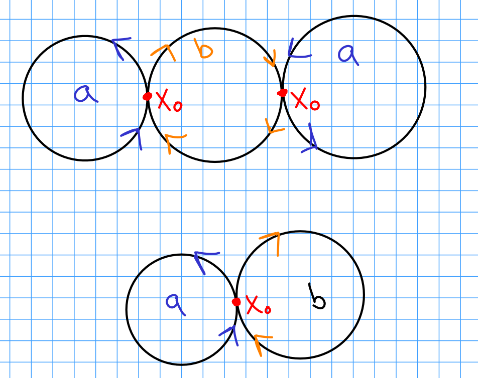

## 4.10 9 (Spring ’05) $\work$

1. Suppose $Y$ is an $n$-fold connected covering space of the torus $S^1 \times S^1$. Up to homeomorphism, what is $Y$? Justify your answer.
2. Let $X$ be the topological space obtained by deleting a disk from a torus. Suppose $Y$ is a 3-fold covering space of $X$.

   What surfaces could $Y$ be? Justify your answer, but you need not exhibit the covering maps explicitly.

## 4.11 10 (Spring ’07) $\work$

Let $S$ be a connected surface, and let $U$ be a connected open subset of $S$. Let $p : \tilde S \to S$ be the universal cover of $S$. Show that $p^{-1}(U )$ is connected if and only if the homeomorphism $i_\ast : \pi_1 (U ) \to \pi_1 (S)$ induced by the inclusion $i : U \to S$ is onto.

## 4.12 11 (Fall ’10) $\work$

Suppose that X has universal cover $p : \tilde X \to X$ and let $A \subset X$ be a subspace with $p(\tilde a) = a \in A$. Show that there is a group isomorphism
$$\begin{align*}
\ker(\pi_1 (A, a) \to \pi_1 (X, a)) \cong \pi_1 (p^{-1}A, \mkern 1.5mu\overline{\mkern-1.5mua\mkern-1.5mu}\mkern 1.5mu)
.\end{align*}$$

## 4.13 12 (Fall ’14) $\work$

Prove that every continuous map $f : {\mathbb{RP}}^2 \to S^1$ is homotopic to a constant.

> Hint: think about covering spaces.

## 4.14 13 (Spring ’16) $\work$

Prove that the free group on two generators contains a subgroup isomorphic to the free group on five generators by constructing an appropriate covering space of $S^1 \lor S^1$.

## 4.15 14 (Fall ’12) $\work$

Use covering space theory to show that ${\mathbb{Z}}_2 \ast {\mathbb{Z}}$ (that is, the free product of ${\mathbb{Z}}_2$ and ${\mathbb{Z}}$) has two subgroups of index 2 which are not isomorphic to each other.

## 4.16 15 (Spring ’17) $\work$

1. Show that any finite index subgroup of a finitely generated free group is free. State clearly any facts you use about the fundamental groups of graphs.
2. Prove that if $N$ is a nontrivial normal subgroup of infinite index in a finitely generated free group $F$ , then $N$ is not finitely generated.

## 4.17 16 (Spring ’19) $\work$

Let $p : X \to Y$ be a covering space, where $X$ is compact, path-connected, and locally path-connected.

Prove that for each $x \in X$ the set $p^{-1}(\left\{{p(x)}\right\})$ is finite, and has cardinality equal to the index of $p_* (\pi_1 (X, x))$ in $\pi_1 (Y, p(x))$.

# 5 Cell Complexes and Adjunction Spaces

## 5.1 1 (Fall ’07) $\work$

Describe a cell complex structure on the torus $T = S^1 \times S^1$ and use this to compute the homology groups of $T$.

> To justify your answer you will need to consider the attaching maps in detail.

## 5.2 2 (Fall ’04) $\work$

Let $X$ be the space formed by identifying the boundary of a Möbius band with a meridian of the torus $T^2$.

Compute $\pi_1 (X)$ and $H_* (X)$.

## 5.3 3 (Spring ’06) $\work$

Compute the homology of the space $X$ obtained by attaching a Möbius band to ${\mathbb{RP}}^2$ via a homeomorphism of its boundary circle to the standard ${\mathbb{RP}}^1$ in ${\mathbb{RP}}^2$.

## 5.4 4 (Spring ’14) $\work$

Let $X$ be a space obtained by attaching two 2-cells to the torus $S^1 \times S^1$, one along a simple closed curve $\left\{{x}\right\} \times S^1$ and the other along $\left\{{y}\right\} \times S^1$ for two points $x \neq y$ in $S^1$ .

### 5.4.1 a

Draw an embedding of $X$ in ${\mathbb{R}}^3$ and calculate its fundamental group.

### 5.4.2 b

Calculate the homology groups of $X$.

## 5.5 5 (Fall ’07) $\work$

Let $X$ be the space obtained as the quotient of a disjoint union of a 2-sphere $S^2$ and a torus $T = S^1 \times S^1$ by identifying the equator in $S^2$ with a circle $S^1 \times \left\{{p}\right\}$ in $T$.

Compute the homology groups of $X$.

## 5.6 6 (Spring ’06) $\work$

Let $X = S^2 / \left\{{p_1 = \cdots = p_k }\right\}$ be the topological space obtained from the 2-sphere by identifying $k$ distinct points on it ($k \geq 2$).

Find:

1. The fundamental group of $X$.
2. The Euler characteristic of $X$.
3. The homology groups of $X$.

## 5.7 7 (Fall ’16) $\work$

Let $X$ be the topological space obtained as the quotient of the sphere $S^2 = \left\{{\mathbf{x} \in {\mathbb{R}}^3 {~\mathrel{\Big|}~}{\left\lVert {\mathbf{x}} \right\rVert} = 1}\right\}$ under the equivalence relation $\mathbf{x} \sim -\mathbf{x}$ for $\mathbf{x}$ in the equatorial circle, i.e. for $\mathbf{x} = (x_1, x_2, 0)$.

Calculate $H_* (X; {\mathbb{Z}})$ from a CW complex description of $X$.

## 5.8 8 (Fall ’17) $\work$

Compute, by any means available, the fundamental group and all the homology groups of the space obtained by gluing one copy $A$ of $S^2$ to another copy $B$ of $S^2$ via a two-sheeted covering space map from the equator of $A$ onto the equator of $B$.

## 5.9 9 (Spring ’14) $\work$

Use cellular homology to calculate the homology groups of $S^n \times S^m$.

## 5.10 10 (Fall ’09/Fall ’12) $\work$

Denote the points of $S^1 \times I$ by $(z, t)$ where $z$ is a unit complex number and $0 \leq t \leq 1$. Let $X$ denote the quotient of $S^1 \times I$ given by identifying $(z, 1)$ and $(z_2 , 0)$ for all $z \in S^1$.

Give a cell structure, with attaching maps, for $X$, and use it to compute $\pi_1 (X, \ast)$ and $H_1 (X)$.

## 5.11 11 (Spring ’15) $\work$

Let $X = S_1 \cup S_2 \subset {\mathbb{R}}^3$ be the union of two spheres of radius 2, one about $(1, 0, 0)$ and the other about $(-1, 0, 0)$, i.e.
$$\begin{align*}
S_1 &= \left\{{(x, y,z) \mathrel{\Big|}(x-1)^2 + y^2 +z^2 = 4}\right\} \\
S_2 &= \left\{{(x, y, z) \mathrel{\Big|}(x + 1)^2 + y^2 + z^2 = 4}\right\}
.\end{align*}$$

1. Give a description of $X$ as a CW complex.
2. Write out the cellular chain complex of $X$.
3. Calculate $H_* (X; Z)$.

## 5.12 12 (Spring ’06) $\work$

Let $M$ and $N$ be finite CW complexes.

1. Describe a cellular structure of $M \times N$ in terms of the cellular structures of $M$ and $N$.
2. Show that the Euler characteristic of $M \times N$ is the product of the Euler characteristics of $M$ and $N$.

## 5.13 13 (Spring ’07) $\work$

Suppose the space $X$ is obtained by attaching a 2-cell to the torus $S^1 \times S^1$.

In other words, $X$ is the quotient space of the disjoint union of the closed disc ${\mathbb{D}}^2$ and the torus $S^1 \times S^1$ by the identification $x \sim f(x)$ where $S^1$ is the boundary of the unit disc and $f : S^1 \to S^1 \times S^1$ is a continuous map.

What are the possible homology groups of $X$? Justify your answer.

## 5.14 14 (Spring ’15) $\work$

Let $X$ be the topological space constructed by attaching a closed 2-disk ${\mathbb{D}}^2$ to the circle $S^1$ by a continuous map $\partial{\mathbb{D}}^2 \to S^1$ of degree $d > 0$ on the boundary circle.

1. Show that every continuous map $X \to X$ has a fixed point.
2. Explain how to obtain all the connected covering spaces of $X$.

## 5.15 15 (Spring ’11) $\work$

Let $X$ be a topological space obtained by attaching a 2-cell to ${\mathbb{RP}}^2$ via some map $f: S^1 \to {\mathbb{RP}}^2$ .

What are the possibilities for the homology $H_* (X; Z)$?

## 5.16 16 (Spring ’12) $\work$

For any integer $n \geq 2$ let $X_n$ denote the space formed by attaching a 2-cell to the circle $S^1$ via the attaching map
$$\begin{align*}
a_n: S^1 &\to S^1 \\
e^{i\theta} &\mapsto e^{in\theta}
.\end{align*}$$

### 5.16.1 a

Compute the fundamental group and the homology of $X_n$.

### 5.16.2 b

Exactly one of the $X_n$ (for $n \geq 2$) is homeomorphic to a surface. Identify, with proof, both this value of $n$ and the surface that $X_n$ is homeomorphic to (including a description of the homeomorphism).

## 5.17 17 (Spring ’09) $\work$

Let $X$ be a CW complex and let $\pi : Y \to X$ be a covering space.

### 5.17.1 a

Show that $Y$ is compact iff $X$ is compact and $\pi$ has finite degree.

### 5.17.2 b

Assume that $\pi$ has finite degree $d$. Show show that $\chi (Y ) = d \chi (X)$.

### 5.17.3 c

Let $\pi :{\mathbb{RP}}^N \to X$ be a covering map. Show that if $N$ is even, $\pi$ is a homeomorphism.

## 5.18 18 (Spring ’18) $\work$

For topological spaces $X, Y$ the **mapping cone** $C(f )$ of a map $f : X \to Y$ is defined to be the quotient space
$$\begin{align*}
(X \times [0, 1]){\textstyle\coprod}Y / \sim &{\quad \operatorname{where} \quad} \\
(x, 0) &\sim (x', 0) {\quad \operatorname{for all} \quad} x, x' \in X \text{ and } \\
(x, 1) &\sim f (x) {\quad \operatorname{for all } \quad} x \in X
.\end{align*}$$

Let $\phi_k : S^n \to S^n$ be a degree $k$ map for some integer $k$.

Find $H_i(C(\phi_k ))$ for all $i$.

## 5.19 Spring 2019 #7 $\done$

For $f:X\to Y$, the *mapping cone* of $f$ is defined as
$$\begin{align*}
C_f \mathrel{\vcenter{:}}=\qty{X\times I} {\textstyle\coprod}Y/\sim \\
(x, 0) \sim (x', 0) \quad \text{for all }x, x'\in X\\
(x, 1) \sim f(x)
.\end{align*}$$

Let $\phi_k: S^1\to S^1$ be a $k{\hbox{-}}$fold covering and find $\pi_1\qty{C_f}$.

Let $f: S^1 \xrightarrow{\times k} S^1$.

**Claim:** The inclusion $S^1 \to C_\phi$ induces an isomorphism $\pi_1(C_\phi) \cong \pi_1(S^1) / H$ where $H = N_{\pi_1(S^1)}(\left\langle{f^*}\right\rangle)$ is the normal subgroup generated by the induced map $f^* \pi_1(S^1) \to \pi_1(S^1)$.

## 5.20 19 (Fall ’18) $\work$

Prove that a finite CW complex must be Hausdorff.

# 6 Homology and Degree Theory

## 6.1 1 (Spring ’09) $\work$

Compute the homology of the one-point union of $S^1 \times S^1$ and $S^1$.

## 6.2 2 (Fall ’06) $\work$

1. State the **Mayer-Vietoris theorem**.
2. Use it to compute the homology of the space $X$ obtained by gluing two solid tori along their boundary as follows. Let ${\mathbb{D}}^2$ be the unit disk and let $S^1$ be the unit circle in the complex plane ${\mathbb{C}}$. Let $A = S^1 \times {\mathbb{D}}^2$ and $B = {\mathbb{D}}^2 \times S^1$.

Then $X$ is the quotient space of the disjoint union $A {\textstyle\coprod}B$ obtained by identifying $(z, w) \in A$ with $(zw^3 , w) \in B$ for all $(z, w) \in S^1 \times S^1$.

## 6.3 3 (Fall ’12) $\work$

Let $A$ and $B$ be circles bounding disjoint disks in the plane $z = 0$ in ${\mathbb{R}}^3$. Let $X$ be the subset of the upper half-space of ${\mathbb{R}}^3$ that is the union of the plane $z = 0$ and a (topological) cylinder that intersects the plane in $\partial C = A \cup B$.

Compute $H_* (X)$ using the Mayer–Vietoris sequence.

## 6.4 4 (Fall ’14) $\work$

Compute the integral homology groups of the space $X = Y \cup Z$ which is the union of the sphere
$$\begin{align*}
Y = \left\{{x^2 + y^2 + z^2 = 1}\right\}
\end{align*}
and the ellipsoid
\begin{align*}
Z = \left\{{x^2 + y^2 + {z^2 \over 4} = 1}\right\}
.\end{align*}$$

## 6.5 5 (Spring ’08) $\work$

Let $X$ consist of two copies of the solid torus ${\mathbb{D}}^2 \times S^1$, glued together by the identity map along the boundary torus $S^1 \times S^1$. Compute the homology groups of $X$.

## 6.6 6 (Spring ’17) $\work$

Use the circle along which the connected sum is performed and the Mayer-Vietoris long exact sequence to compute the homology of ${\mathbb{RP}}^2 \# {\mathbb{RP}}^2$.

## 6.7 7 (Fall ’15) $\work$

Express a Klein bottle as the union of two annuli.

Use the Mayer Vietoris sequence and this decomposition to compute its homology.

## 6.8 8 (Spring ’09) $\work$

Let $X$ be the topological space obtained by identifying three distinct points on $S^2$. Calculate $H_* (X; Z)$.

## 6.9 9 (Fall ’05) $\work$

Compute $H_0$ and $H_1$ of the complete graph $K_5$ formed by taking five points and joining each pair with an edge.

## 6.10 10 (Fall ’18) $\work$

Compute the homology of the subset $X \subset {\mathbb{R}}^3$ formed as the union of the unit sphere, the $z{\hbox{-}}$axis, and the $xy{\hbox{-}}$plane.

## 6.11 11 (Spring ’05/Fall ’13) $\work$

Let $X$ be the topological space formed by filling in two circles $S^1 \times \left\{{p_1 }\right\}$ and $S^1 \times \left\{{p_2 }\right\}$ in the torus $S^1 \times S^1$ with disks.

Calculate the fundamental group and the homology groups of $X$.

## 6.12 12 (Spring ’19) $\work$

1. Consider the quotient space
   $$\begin{align*}
   T^2 = {\mathbb{R}}^2 / \sim {\quad \operatorname{where} \quad} (x, y) \sim (x + m, y + n) \text{ for } m, n \in {\mathbb{Z}}
   ,\end{align*}
   and let \(A\) be any \(2 \times 2\) matrix whose entries are integers such that \(\det A = 1\).$$

Prove that the action of $A$ on ${\mathbb{R}}^2$ descends via the quotient ${\mathbb{R}}^2 \to T^2$ to induce a homeomorphism $T^2 \to T^2$.

2. Using this homeomorphism of $T^2$, we define a new quotient space
   $$\begin{align*}
   T_A^3 \mathrel{\vcenter{:}}={T^2\times{\mathbb{R}}\over \sim} {\quad \operatorname{where} \quad} ((x, y), t) \sim (A(x, y), t + 1)
   \end{align*}$$

Compute $H_1 (T_A^3 )$ if $A=\left(\begin{array}{ll} 1 & 1 \\ 0 & 1 \end{array}\right).$

## 6.13 13 (Spring ’12) $\work$

Give a self-contained proof that the zeroth homology $H_0 (X)$ is isomorphic to ${\mathbb{Z}}$ for every path-connected space $X$.

## 6.14 14 (Fall ’18) $\work$

It is a fact that if $X$ is a single point then $H_1 (X) = \left\{{0}\right\}$.

One of the following is the correct justification of this fact in terms of the singular chain complex.

Which one is correct and why is it correct?

1. $C_1 (X) = \left\{{0}\right\}$.
2. $C_1 (X) \neq \left\{{0}\right\}$ but $\ker \partial_1 = 0$ with $\partial_1 : C_1 (X) \to C_0 (X)$.
3. $\ker \partial_1 \neq 0$ but $\ker \partial_1 = \operatorname{im}\partial_2$ with $\partial_2 : C_2 (X) \to C_1 (X)$.

## 6.15 15 (Fall ’10) $\work$

Compute the homology groups of $S^2 \times S^2$.

## 6.16 16 (Fall ’16) $\work$

Let $\Sigma$ be a closed orientable surface of genus $g$. Compute $H_i(S^1 \times \Sigma; Z)$ for $i = 0, 1, 2, 3$.

## 6.17 17 (Spring ’07) $\work$

Prove that if $A$ is a retract of the topological space $X$, then for all nonnegative integers $n$ there is a group $G_n$ such that $H_{n} (X) \cong H_{n} (A) \oplus G_n$.

> Here $H_{n}$ denotes the $n$th singular homology group with integer coefficients.

## 6.18 18 (Spring ’13) $\work$

Does there exist a map of degree 2013 from $S^2 \to S^2$.

## 6.19 19 (Fall ’18) $\work$

For each $n \in {\mathbb{Z}}$ give an example of a map $f_n : S^2 \to S^2$.

For which $n$ must any such map have a fixed point?

## 6.20 20 (Spring ’09) $\work$

1. What is the degree of the antipodal map on the $n$-sphere?

(No justification required)

2. Define a CW complex homeomorphic to the real projective $n{\hbox{-}}$space ${\mathbb{RP}}^n$.
3. Let $\pi : {\mathbb{RP}}^n \to X$ be a covering map. Show that if $n$ is even, $\pi$ is a homeomorphism.

## 6.21 21 (Fall ’17) $\work$

Let $A \subset X$. Prove that the relative homology group $H_0 (X, A)$ is trivial if and only if $A$ intersects every path component of $X$.

## 6.22 22 (Fall ’18) $\work$

Let ${\mathbb{D}}$ be a closed disk embedded in the torus $T = S^1 \times S^1$ and let $X$ be the result of removing the interior of ${\mathbb{D}}$ from $T$ . Let $B$ be the boundary of $X$, i.e. the circle boundary of the original closed disk ${\mathbb{D}}$.

Compute $H_i (T, B)$ for all $i$.

## 6.23 23 (Fall ’11) $\work$

For any $n \geq 1$ let $S^n = \left\{{(x_0 , \cdots , x_n )\mathrel{\Big|}\sum x_i^2 =1}\right\}$ denote the $n$ dimensional unit sphere and let
$$\begin{align*}E = \left\{{(x_0 , . . . , x_n )\mathrel{\Big|}x_n = 0}\right\}\end{align*}
denote the “equator.”$$

Find, for all $k$, the relative homology $H_k (S^n , E)$.

## 6.24 24 (Spring ’12/Spring ’15) $\work$

Suppose that $U$ and $V$ are open subsets of a space $X$, with $X = U \cup V$. Find, with proof, a general formula relating the Euler characteristics of $X, U, V$, and $U \cap V$.

> You may assume that the homologies of $U, V, U \cap V, X$ are finite-dimensional so that their Euler characteristics are well defined.

## 6.25 Spring 2021 #6

For each of the following spaces, compute the fundamental group and the homology groups.

1. The graph $\Theta$ consisting of two edges and three vertices connecting them.
2. The 2-dimensional cell complex $\Theta_2$ consisting of a closed circle and three 2-dimensional disks each having boundary running once around that circle.

## 6.26 Spring 2021 #7

Prove directly from the definition that the 0th singular homology of a nonempty path-connected space is isomorphic to ${\mathbb{Z}}$.

## 6.27 Spring 2021 #9

Prove that for every continuous map $f: S^{2n} \to S^{2n}$ there is a point $x\in S^{2n}$ such that either $f(x) = x$ or $f(x) = -x$.

> You may use standard facts about degrees of maps of spheres, including that the antipodal map on $S^{2n}$ has degree $d=-1$.

# 7 Surfaces

## 7.1 1 (Fall ’05) $\work$

State the classification theorem for surfaces (compact, without boundary, but not necessarily orientable). For each surface in the classification, indicate the structure of the first homology group and the value of the Euler characteristic.

Also, explain briefly how the 2-holed torus and the connected sum ${\mathbb{RP}}^2 \# {\mathbb{RP}}^2$ fit into the classification.

## 7.2 2 (Spring ’16) $\work$

Give a list without repetitions of all compact surfaces (orientable or non-orientable and with or without boundary) that have Euler characteristic negative one.

Explain why there are no repetitions on your list.

## 7.3 3 (Spring ’07) $\work$

Describe the topological classification of all compact connected surfaces $M$ without boundary having Euler characteristic $\chi(M )\geq -2$.

No proof is required.

## 7.4 4 (Spring ’09) $\work$

How many surfaces are there, up to homeomorphism, which are:

- Connected,
- Compact,
- Possibly with boundary,
- Possibly nonorientable, and
- With Euler characteristic -3?

Describe one representative from each class.

## 7.5 5 (Fall ’13) $\work$

Prove that the Euler characteristic of a compact surface with boundary which has $k$ boundary components is less than or equal to $2 - k$.

## 7.6 6 (Spring ’13) $\work$

What surface is represented by the $6{\hbox{-}}$gon with edges identified according to the symbol $xyzxy^{-1}z^{-1}$ ?

## 7.7 7 (Spring ’15) $\work$

Let $X$ be the topological space obtained as the quotient space of a regular $2n{\hbox{-}}$gon ($n \geq 2$) in ${\mathbb{R}}^2$ by identifying opposite edges via translations in the plane.

First show that X is a compact, orientable surface without boundary, and then identify its genus as a function of $n$.

## 7.8 8 (Fall ’10) $\work$

### 7.8.1 a

Show that any compact connected surface with nonempty boundary is homotopy equivalent to a wedge of circles

> Hint: you may assume that any compact connected surface without boundary is given by identifying edges of a polygon in pairs.

### 7.8.2 b

For each surface appearing in the classification of compact surfaces with nonempty boundary, say how many circles are needed in the wedge from part (a).

> Hint: you should be able to do this even if you have not done part (a).

## 7.9 9 (Fall ’04) $\work$

Let $M_g^2$ be the compact oriented surface of genus $g$.

Show that there exists a continuous map $f : M_g^2 \to S^2$ which is not homotopic to a constant map.

## 7.10 10 (Spring ’11)

Show that ${\mathbb{RP}}^2 \lor S^1$ is *not* homotopy equivalent to a compact surface (possibly with boundary).

## 7.11 11 (Fall ’14) $\work$

Identify (with proof, but of course you can appeal to the classification of surfaces) all of the compact surfaces without boundary that have a cell decomposition having exactly one 0-cell and exactly two 1-cells (with no restriction on the number of cells of dimension larger than 1).

## 7.12 12 (Fall ’11) $\work$

For any natural number $g$ let $\Sigma_g$ denote the (compact, orientable) surface of genus $g$.

Determine, with proof, all valued of $g$ with the property that there exists a covering space $\pi : \Sigma_5 \to \Sigma_g$ .

> Hint: How does the Euler characteristic behave for covering spaces?

## 7.13 13 (Spring ’14) $\work$

Find *all* surfaces, orientable and non-orientable, which can be covered by a closed surface (i.e. compact with empty boundary) of genus 2. Prove that your answer is correct.

## 7.14 14 (Spring ’18) $\work$

### 7.14.1 a

Write down (without proof) a presentation for $\pi_1 (\Sigma_2 , p)$ where $\Sigma_2$ is a closed, connected, orientable genus 2 surface and $p$ is any point on $\Sigma_2$ .

### 7.14.2 b

Show that $\pi_1 (\Sigma_2 , p)$ is not abelian by showing that it surjects onto a free group of rank 2.

### 7.14.3 c

Show that there is no covering space map from $\Sigma_2$ to $S^1 \times S^1$ . You may use the fact that $\pi_1 (S^1 \times S^1 ) \cong {\mathbb{Z}}^2$ together with the result in part (b) above.

## 7.15 15 (Fall ’16) $\work$

Give an example, with explanation, of a closed curve in a surfaces which is not nullhomotopic but is nullhomologous.

## 7.16 16 (Fall ’17) $\work$

Let $M$ be a compact orientable surface of genus $2$ without boundary.

Give an example of a pair of loops
$$\begin{align*}\gamma_0 , \gamma_1 : S^1 \to M\end{align*}
with \(\gamma_0 (1) = \gamma_1 (1)\) such that there is a continuous map \(\Gamma: [0, 1] \times S^1 \to M\) such that
\begin{align*}
\Gamma(0, t) = \gamma_0 (t), \quad \Gamma(1, t) = \gamma_1 (t) {\quad \operatorname{for all} \quad} t \in S^1
,\end{align*}
but such that there is no such map \(\Gamma\) with the additional property that \(\Gamma_s (1) = \gamma_0 (1)\) for all \(s \in [0, 1]\).$$

(You are not required to prove that your example satisfies the stated property.)

## 7.17 17 (Fall ’18) $\work$

Let $C$ be cylinder. Let $I$ and $J$ be disjoint closed intervals contained in $\partial C$.

What is the Euler characteristic of the surface $S$ obtained by identifying $I$ and $J$?

Can all surface with nonempty boundary and with this Euler characteristic be obtained from this construction?

## 7.18 18 (Spring ’19) $\work$

Let $\Sigma$ be a compact connected surface and let $p_1, \cdots , p_k \in \Sigma$.

Prove that $H_2 \qty{\Sigma \setminus \cup_{i=1}^k {p_i} } = 0$.

## 7.19 Spring 2021 #8

Let $\Sigma_{g, n}$ denote the compact oriented surface of genus $g$ with $n$ boundary components.

1. Show that $\Sigma_{0, 3}$ and $\Sigma_{1, 1}$ are both homotopy equivalent to $S_1 \vee S^1$.
2. Give a complete classification of pairs $(g, n)$ and $(g', n')$ for which $\Sigma_{g, n}$ is homotopy equivalent to $\Sigma_{g', n'}$.

# 8 Fixed Points

## 8.1 1 (Fall ’14) $\work$

Prove that, for every continuous map $f : B^2 \to B^2$, there is a point $x$ such that $f (x) = x$.

> This is the $n = 2$ case of the Brouwer fixed point theorem; your proof shouldn’t appeal to either of the Brouwer or the Lefschetz fixed point theorems.

## 8.2 2 (Spring ’18) $\work$

Prove or disprove:

Every continuous map from $S^2$ to $S^2$ has a fixed point.

## 8.3 3 (Spring ’11) $\work$

1. State the **Lefschetz Fixed Point Theorem** for a finite simplicial complex $X$.
2. Use degree theory to prove this theorem in case $X = S^n$.

## 8.4 4 (Spring ’12) $\work$

### 8.4.1 a

Prove that for every continuous map $f : S^2 \to S^2$ there is some $x$ such that either $f (x) = x$ or $f (x) = -x$.

> Hint: Where $A : S^2 \to S^2$ is the antipodal map, you are being asked to prove that either $f$ or $A \circ f$ has a fixed point.

### 8.4.2 b

Exhibit a continuous map $f : S^3 \to S^3$ such that for every $x \in S^3$, $f (x)$ is equal to neither $x$ nor $-x$.

> Hint: It might help to first think about how you could do this for a map from $S^1$ to $S^1$.

## 8.5 5 (Spring ’14) $\work$

Show that a map $S^n \to S^n$ has a fixed point unless its degree is equal to the degree of the antipodal map $a : x \to -x$.

## 8.6 6 (Spring ’08) $\work$

Give an example of a homotopy class of maps of $S^1 \lor S^1$ each member of which must have a fixed point, and also an example of a map of $S^1 \lor S^1$ which doesn’t have a fixed point.

## 8.7 7 (Spring ’17) $\work$

Prove or disprove:

Every map from ${\mathbb{RP}}^2 \lor {\mathbb{RP}}^2$ to itself has a fixed point.

## 8.8 8 (Fall ’09) $\work$

Find all homotopy classes of maps from $S^1 \times {\mathbb{D}}^2$ to itself such that every element of the homotopy class has a fixed point.

## 8.9 9 (Spring ’10) $\work$

Let $X$ and $Y$ be finite connected simplicial complexes and let $f : X \to Y$ and $g : Y \to X$ be basepoint-preserving maps.

Show that no matter how you homotope $f \lor g : X \lor Y \to X \lor Y$, there will always be a fixed point.

## 8.10 10 (Fall ’12) $\work$

Let $f = \operatorname{id}_{{\mathbb{RP}}^2} \lor \ast$ and $g = \ast \lor id_{S^1}$ be two maps of ${\mathbb{RP}}^2 \lor S^1$ to itself where $\ast$ denotes the constant map of a space to its basepoint.

Show that one map is homotopic to a map with no fixed points, while the other is not.

## 8.11 11 (Spring ’09) $\work$

View the torus $T$ as the quotient space ${\mathbb{R}}^2 /{\mathbb{Z}}^2$.

Let $A$ be a $2 \times 2$ matrix with ${\mathbb{Z}}$ coefficients.

### 8.11.1 a

Show that the linear map $A : {\mathbb{R}}^2 \to {\mathbb{R}}^2$ descends to a continuous map ${\mathcal{A}}: T \to T$.

### 8.11.2 b

Show that, with respect to a suitable basis for $H_1 (T ; {\mathbb{Z}})$, the matrix $A$ represents the map induced on $H_1$ by ${\mathcal{A}}$.

### 8.11.3 c

Find a necessary and sufficient condition on $A$ for ${\mathcal{A}}$ to be homotopic to the identity.

### 8.11.4 d

Find a necessary and sufficient condition on $A$ for ${\mathcal{A}}$ to be homotopic to a map with no fixed points.

## 8.12 12 (Spring ’19) $\work$

### 8.12.1 a

Use the Lefschetz fixed point theorem to show that any degree-one map $f : S^2 \to S^2$ has at least one fixed point.

### 8.12.2 b

Give an example of a map $f : {\mathbb{R}}^2 \to {\mathbb{R}}^2$ having no fixed points.

### 8.12.3 c

Give an example of a degree-one map $f : S^2 \to S^2$ having exactly one fixed point.

## 8.13 13 (Fall ’10) $\work$

For which compact connected surfaces $\Sigma$ (with or without boundary) does there exist a continuous map $f : \Sigma \to \Sigma$ that is homotopic to the identity and has no fixed point?

Explain your answer fully.

## 8.14 14 (Spring ’16) $\work$

Use the Brouwer fixed point theorem to show that an $n \times n$ matrix with nonnegative entries has a real eigenvalue.

# 9 Miscellaneous Algebraic Topology

## 9.1 1 (Fall ’14) $\work$

Prove that ${\mathbb{R}}^2$ is not homeomorphic to ${\mathbb{R}}^n$ for $n > 2$.

## 9.2 2 (Spring ’12) $\work$

Prove that any finite tree is contractible, where a **tree** is a connected graph that contains no closed edge paths.

## 9.3 3 (Spring ’13) $\done$

Show that any continuous map $f : {\mathbb{RP}}^2 \to S^1 \times S^1$ is necessarily null-homotopic.

- Two techniques:
  - Show $f_* = 0$
  - Lift to a contractible universal cover.
- Any continuous map ${\mathbb{RP}}^2 \xrightarrow{f} S^1\times S^1$ induces a group morphism $\pi_1 {\mathbb{RP}}^2 \xrightarrow{f_*} \pi_1(S^1\times S^1)$
- Identify $\pi_1 {\mathbb{RP}}^2 = {\mathbb{Z}}/2{\mathbb{Z}}$ and $\pi_1(S^1\times S^1) = \pi_1 S^1 \times\pi_1 S^1 = {\mathbb{Z}}^2$.
- But as a ${\mathbb{Z}}{\hbox{-}}$module morphism, $f_*$ will preserve torsion submodules, and since ${\mathbb{Z}}^2$ is free we must have $f_* = 0$.
- Lemma: $f_* = 0$ implies $f$ is nullhomotopic.
  - Note that $\widetilde{S^1\times S^1} = {\mathbb{R}}^2$.

## 9.4 4 (Fall ’11) $\done$

Prove that, for $n \geq 2$, every continuous map $f: {\mathbb{RP}}^n \to S^1$ is null-homotopic.

- Any continuous map ${\mathbb{RP}}^n \xrightarrow{f} S^1$ induces a group morphism $\pi_1{\mathbb{RP}}^n \xrightarrow{f_*} \pi_1S^1$
- Identify $\pi_1{\mathbb{RP}}^n = {\mathbb{Z}}/2{\mathbb{Z}}$ and $\pi_1S^1 = {\mathbb{Z}}$ to obtain a group morphism $f_*: {\mathbb{Z}}/2{\mathbb{Z}}\to {\mathbb{Z}}$.
- Claim: $f_* = 0$.
  - Recognizing this as a map of ${\mathbb{Z}}{\hbox{-}}$modules, we must have
    $$\begin{align*}
    0 = [2]_2 = 2\cdot [1]_2 \implies 0 = f_*(0) = 2\cdot f_*([1]_2)
    .\end{align*}
    since \({\mathbb{Z}}{\hbox{-}}\)module maps send 0 to 0.$$
  - But no element of the image ${\mathbb{Z}}$ is annihilated by $2$, so $f_*$ can only be the zero map.
- But then $f$ is nullhomotopic.
- Lemma: $f_* = 0$ implies $f$ is nullhomotopic.

## 9.5 5 (Spring ’06) $\work$

Let $S^2 \to {\mathbb{RP}}^2$ be the universal covering map.

Is this map null-homotopic? Give a proof of your answer.

## 9.6 6 (Spring ’17) $\done$

Suppose that a map $f : S^3 \times S^3 \to {\mathbb{RP}}^3$ is not surjective.

Prove that $f$ is homotopic to a constant function.

## 9.7 7 (Fall ’06) $\work$

Prove that there does not exist a continuous map $f : S^2 \to S^2$ from the unit sphere in ${\mathbb{R}}^3$ to itself such that $f (\mathbf{x}) \perp \mathbf{x}$ (as vectors in ${\mathbb{R}}^3$ for all $\mathbf{x} \in S^2$).

## 9.8 8 (Spring ’08) $\work$

Let $f$ be the map of $S^1 \times [0, 1]$ to itself defined by
$$\begin{align*}
f (e^{i\theta} , s) = (e^{i(\theta+2\pi s)} , s)
,\end{align*}
so that \(f\) restricts to the identity on the two boundary circles of \(S^1 \times [0, 1]\).$$

Show that $f$ is homotopic to the identity by a homotopy $f_t$ that is stationary on one of the boundary circles, but not by any homotopy that is stationary on both boundary circles.

> Hint: Consider what $f$ does to the path $s \mapsto (e^{i\theta_0} , s)$ for fixed $e^{i\theta_0} \in S^1$.

## 9.9 9 (Spring ’17) $\work$

Show that $S^1 \times S^1$ is not the union of two disks (where there is no assumption that the disks intersect along their boundaries).

## 9.10 10 (Spring ’14) $\work$

Suppose that $X \subset Y$ and $X$ is a deformation retract of $Y$.

Show that if $X$ is a path connected space, then $Y$ is path connected.

## 9.11 11 (Spring ’05) $\work$

Do one of the following:

1. Give (with justification) a contractible subset $X \subset {\mathbb{R}}^2$ which is not a retract of ${\mathbb{R}}^2$ .
2. Give (with justification) two topological spaces that have the same homology groups but that are not homotopy equivalent.

## 9.12 12 (Spring ’16) $\work$

Recall that the **suspension** of a topological space, denoted $SX$, is the quotient space formed from $X \times [-1, 1]$ by identifying $(x, 1)$ with $(y, 1)$ for all $x, y \in X$, and also identifying $(x, -1)$ with $(y, -1)$ for all $x, y \in X$.

1. Show that $SX$ is the union of two contractible subspaces.
2. Prove that if $X$ is path-connected then $\pi_1 (SX) = \left\{{0}\right\}$.
3. For all $n \geq 1$, prove that $H_{n} (X) \cong H_{n+1} (SX)$.

# 10 Extra Problems: Algebraic Topology

## 10.1 Algebraic Topology

### 10.1.1 Fundamental Group

- Compute $\pi_1(X)$ where $X \mathrel{\vcenter{:}}= S^2/\sim$, where $x\sim -x$ only for $x$ on the equator $S^1 \hookrightarrow S^2$.
  - Hint: try cellular homology. Should yield $[{\mathbb{Z}}, {\mathbb{Z}}/2{\mathbb{Z}}, {\mathbb{Z}}, 0, \cdots]$.
- Show that if $X = S^2 {\textstyle\coprod}_{\operatorname{id}} S^2$ is a pushout along the equators, then $H_n(X) = [{\mathbb{Z}}, 0, {\mathbb{Z}}^3, 0, \cdots]$.

### 10.1.2 Covering Spaces

- Describe all connected covering spaces of ${\mathbb{RP}}^2 \vee {\mathbb{RP}}^2$.

### 10.1.3 Homology

- Compute the homology of the Klein bottle using the Mayer-Vietoris sequence and a decomposition $K = M {\textstyle\coprod}_f M$
- Use the Kunneth formula to compute $H^*(S^2\times S^2; {\mathbb{Z}})$.
  - Known to be $[{\mathbb{Z}}, 0, {\mathbb{Z}}^2, 0, {\mathbb{Z}}, 0, 0, \cdots]$.
- Compute $H^*(S^2 \vee S^2 \vee S^4)$
  - Known to be $[{\mathbb{Z}}, 0, {\mathbb{Z}}^2, 0, {\mathbb{Z}}, 0, 0, \cdots]$.
- Show that $\chi(\Sigma_g + \Sigma_h) = \chi(\Sigma_g) + \chi(\Sigma_h) - 2$.

# 11 Bibliography